# Project Introduction to Neural Networking: ReneWind Data Analysis by Gabriel Hinojos

# **Problem Statement**

## Business Context

Renewable energy sources play an increasingly important role in the global energy mix, as the effort to reduce the environmental impact of energy production increases.

Out of all the renewable energy alternatives, wind energy is one of the most developed technologies worldwide. The U.S Department of Energy has put together a guide to achieving operational efficiency using predictive maintenance practices.

Predictive maintenance uses sensor information and analysis methods to measure and predict degradation and future component capability. The idea behind predictive maintenance is that failure patterns are predictable and if component failure can be predicted accurately and the component is replaced before it fails, the costs of operation and maintenance will be much lower.

The sensors fitted across different machines involved in the process of energy generation collect data related to various environmental factors (temperature, humidity, wind speed, etc.) and additional features related to various parts of the wind turbine (gearbox, tower, blades, break, etc.).

## Objective

“ReneWind” is a company working on improving the machinery/processes involved in the production of wind energy using machine learning and has collected data of generator failure of wind turbines using sensors. They have shared a ciphered version of the data, as the data collected through sensors is confidential (the type of data collected varies with companies). Data has 40 predictors, 20000 observations in the training set and 5000 in the test set.

The objective is to build various classification models, tune them, and find the best one that will help identify failures so that the generators could be repaired before failing/breaking to reduce the overall maintenance cost. The nature of predictions made by the classification model will translate as follows:

- True positives (TP) are failures correctly predicted by the model. These will result in repairing costs.
- False negatives (FN) are real failures where there is no detection by the model. These will result in replacement costs.
- False positives (FP) are detections where there is no failure. These will result in inspection costs.

It is given that the cost of repairing a generator is much less than the cost of replacing it, and the cost of inspection is less than the cost of repair.

“1” in the target variables should be considered as “failure” and “0” represents “No failure”.

## Data Description

The data provided is a transformed version of the original data which was collected using sensors.

- Train.csv - To be used for training and tuning of models.
- Test.csv - To be used only for testing the performance of the final best model.

Both the datasets consist of 40 predictor variables and 1 target variable.

# **Installing and Importing the necessary libraries**

```python
# Commented out this section as this is run in Google Colab
# Installing the libraries with the specified version
# !pip install --no-deps tensorflow==2.18.0 scikit-learn==1.3.2 matplotlib===3.8.3 seaborn==0.13.2 numpy==1.26.4 pandas==2.2.2 -q --user --no-warn-script-location
```

**Note**:

- After running the above cell, kindly restart the runtime (for Google Colab) or notebook kernel (for Jupyter Notebook), and run all cells sequentially from the next cell.
- On executing the above line of code, you might see a warning regarding package dependencies. This error message can be ignored as the above code ensures that all necessary libraries and their dependencies are maintained to successfully execute the code in **this notebook**.

```python
# import libraries for reading and manipulation of data
import numpy as np
import pandas as pd

# import libraries for time related functions
import time

# import libraries for data visualization
import matplotlib.pyplot as plt
%matplotlib inline
import seaborn as sns
sns.set()

# import libraries to split datasets into training and testing sets
from sklearn.model_selection import train_test_split

# import libraries for data preprocessing
from sklearn.preprocessing import LabelEncoder
from sklearn.preprocessing import OneHotEncoder
from sklearn.preprocessing import StandardScaler

# import libraries for imputing missing values in datasets
from sklearn.impute import SimpleImputer

# import library to compute classification metrics
from sklearn import metrics
from sklearn.metrics import confusion_matrix, accuracy_score, precision_score, recall_score, f1_score, classification_report

# import library to compute class weights
from sklearn.utils.class_weight import compute_class_weight

# import libraries for tensorflow
import tensorflow
import tensorflow as tf #An end-to-end open source machine learning platform
from tensorflow import keras  # High-level neural networks API for deep learning.
from keras import backend   # Abstraction layer for neural network backend engines.
from keras.models import Sequential  # Model for building NN sequentially.
from keras.layers import Dense
from keras.layers import Input
from keras.layers import Dropout
from keras.layers import BatchNormalization

# import the optimzers
from tensorflow.keras.optimizers import SGD, Adam, RMSprop, Adagrad

# import the Recall class
from tensorflow.keras.metrics import Recall

# import library to suppress unnecessary warnings
import warnings
warnings.filterwarnings("ignore")
```

```python
# Set the seed using keras.utils.set_random_seed. This will set:
# 1) `numpy` seed
# 2) backend random seed
# 3) `python` random seed
keras.utils.set_random_seed(812)

# If using TensorFlow, this will make GPU ops as deterministic as possible,
# but it will affect the overall performance, so be mindful of that.
tf.config.experimental.enable_op_determinism()
```

# **Loading the Data**

```python
# run the following lines for Google Colab
from google.colab import drive
drive.mount('/content/drive')
```

```python
# read the dataset from the Google Colab drive Python Course
train = pd.read_csv('/content/drive/MyDrive/Python Course/Train.csv')
test = pd.read_csv('/content/drive/MyDrive/Python Course/Test.csv')
```

```python
# create copy of training and testing data
data = train.copy()
data_test = test.copy()
```

# **Data Overview**

#### Viewing the first and last 5 rows of the training and testing dataset

```python
# pull the first 5 rows of training data from dataset
data.head(5)
```

|  | V1 | V2 | V3 | V4 | V5 | V6 | V7 | V8 | V9 | V10 | ... | V32 | V33 | V34 | V35 | V36 | V37 | V38 | V39 | V40 | Target |
| --- | --- | --- | --- | --- | --- | --- | --- | --- | --- | --- | --- | --- | --- | --- | --- | --- | --- | --- | --- | --- | --- |
| 0 | -4.464606 | -4.679129 | 3.101546 | 0.506130 | -0.221083 | -2.032511 | -2.910870 | 0.050714 | -1.522351 | 3.761892 | ... | 3.059700 | -1.690440 | 2.846296 | 2.235198 | 6.667486 | 0.443809 | -2.369169 | 2.950578 | -3.480324 | 0 |
| 1 | 3.365912 | 3.653381 | 0.909671 | -1.367528 | 0.332016 | 2.358938 | 0.732600 | -4.332135 | 0.565695 | -0.101080 | ... | -1.795474 | 3.032780 | -2.467514 | 1.894599 | -2.297780 | -1.731048 | 5.908837 | -0.386345 | 0.616242 | 0 |
| 2 | -3.831843 | -5.824444 | 0.634031 | -2.418815 | -1.773827 | 1.016824 | -2.098941 | -3.173204 | -2.081860 | 5.392621 | ... | -0.257101 | 0.803550 | 4.086219 | 2.292138 | 5.360850 | 0.351993 | 2.940021 | 3.839160 | -4.309402 | 0 |
| 3 | 1.618098 | 1.888342 | 7.046143 | -1.147285 | 0.083080 | -1.529780 | 0.207309 | -2.493629 | 0.344926 | 2.118578 | ... | -3.584425 | -2.577474 | 1.363769 | 0.622714 | 5.550100 | -1.526796 | 0.138853 | 3.101430 | -1.277378 | 0 |
| 4 | -0.111440 | 3.872488 | -3.758361 | -2.982897 | 3.792714 | 0.544960 | 0.205433 | 4.848994 | -1.854920 | -6.220023 | ... | 8.265896 | 6.629213 | -10.068689 | 1.222987 | -3.229763 | 1.686909 | -2.163896 | -3.644622 | 6.510338 | 0 |

5 rows × 41 columns

```python
# pull the last 5 rows of the training data from the dataset
data.tail(5)
```

|  | V1 | V2 | V3 | V4 | V5 | V6 | V7 | V8 | V9 | V10 | ... | V32 | V33 | V34 | V35 | V36 | V37 | V38 | V39 | V40 | Target |
| --- | --- | --- | --- | --- | --- | --- | --- | --- | --- | --- | --- | --- | --- | --- | --- | --- | --- | --- | --- | --- | --- |
| 19995 | -2.071318 | -1.088279 | -0.796174 | -3.011720 | -2.287540 | 2.807310 | 0.481428 | 0.105171 | -0.586599 | -2.899398 | ... | -8.273996 | 5.745013 | 0.589014 | -0.649988 | -3.043174 | 2.216461 | 0.608723 | 0.178193 | 2.927755 | 1 |
| 19996 | 2.890264 | 2.483069 | 5.643919 | 0.937053 | -1.380870 | 0.412051 | -1.593386 | -5.762498 | 2.150096 | 0.272302 | ... | -4.159092 | 1.181466 | -0.742412 | 5.368979 | -0.693028 | -1.668971 | 3.659954 | 0.819863 | -1.987265 | 0 |
| 19997 | -3.896979 | -3.942407 | -0.351364 | -2.417462 | 1.107546 | -1.527623 | -3.519882 | 2.054792 | -0.233996 | -0.357687 | ... | 7.112162 | 1.476080 | -3.953710 | 1.855555 | 5.029209 | 2.082588 | -6.409304 | 1.477138 | -0.874148 | 0 |
| 19998 | -3.187322 | -10.051662 | 5.695955 | -4.370053 | -5.354758 | -1.873044 | -3.947210 | 0.679420 | -2.389254 | 5.456756 | ... | 0.402812 | 3.163661 | 3.752095 | 8.529894 | 8.450626 | 0.203958 | -7.129918 | 4.249394 | -6.112267 | 0 |
| 19999 | -2.686903 | 1.961187 | 6.137088 | 2.600133 | 2.657241 | -4.290882 | -2.344267 | 0.974004 | -1.027462 | 0.497421 | ... | 6.620811 | -1.988786 | -1.348901 | 3.951801 | 5.449706 | -0.455411 | -2.202056 | 1.678229 | -1.974413 | 0 |

5 rows × 41 columns

```python
# pull the first 5 rows of testing data from dataset
data_test.head(5)
```

|  | V1 | V2 | V3 | V4 | V5 | V6 | V7 | V8 | V9 | V10 | ... | V32 | V33 | V34 | V35 | V36 | V37 | V38 | V39 | V40 | Target |
| --- | --- | --- | --- | --- | --- | --- | --- | --- | --- | --- | --- | --- | --- | --- | --- | --- | --- | --- | --- | --- | --- |
| 0 | -0.613489 | -3.819640 | 2.202302 | 1.300420 | -1.184929 | -4.495964 | -1.835817 | 4.722989 | 1.206140 | -0.341909 | ... | 2.291204 | -5.411388 | 0.870073 | 0.574479 | 4.157191 | 1.428093 | -10.511342 | 0.454664 | -1.448363 | 0 |
| 1 | 0.389608 | -0.512341 | 0.527053 | -2.576776 | -1.016766 | 2.235112 | -0.441301 | -4.405744 | -0.332869 | 1.966794 | ... | -2.474936 | 2.493582 | 0.315165 | 2.059288 | 0.683859 | -0.485452 | 5.128350 | 1.720744 | -1.488235 | 0 |
| 2 | -0.874861 | -0.640632 | 4.084202 | -1.590454 | 0.525855 | -1.957592 | -0.695367 | 1.347309 | -1.732348 | 0.466500 | ... | -1.318888 | -2.997464 | 0.459664 | 0.619774 | 5.631504 | 1.323512 | -1.752154 | 1.808302 | 1.675748 | 0 |
| 3 | 0.238384 | 1.458607 | 4.014528 | 2.534478 | 1.196987 | -3.117330 | -0.924035 | 0.269493 | 1.322436 | 0.702345 | ... | 3.517918 | -3.074085 | -0.284220 | 0.954576 | 3.029331 | -1.367198 | -3.412140 | 0.906000 | -2.450889 | 0 |
| 4 | 5.828225 | 2.768260 | -1.234530 | 2.809264 | -1.641648 | -1.406698 | 0.568643 | 0.965043 | 1.918379 | -2.774855 | ... | 1.773841 | -1.501573 | -2.226702 | 4.776830 | -6.559698 | -0.805551 | -0.276007 | -3.858207 | -0.537694 | 0 |

5 rows × 41 columns

```python
# pull the last 5 rows of the testing data from the dataset
data_test.tail(5)
```

|  | V1 | V2 | V3 | V4 | V5 | V6 | V7 | V8 | V9 | V10 | ... | V32 | V33 | V34 | V35 | V36 | V37 | V38 | V39 | V40 | Target |
| --- | --- | --- | --- | --- | --- | --- | --- | --- | --- | --- | --- | --- | --- | --- | --- | --- | --- | --- | --- | --- | --- |
| 4995 | -5.120451 | 1.634804 | 1.251259 | 4.035944 | 3.291204 | -2.932230 | -1.328662 | 1.754066 | -2.984586 | 1.248633 | ... | 9.979118 | 0.063438 | 0.217281 | 3.036388 | 2.109323 | -0.557433 | 1.938718 | 0.512674 | -2.694194 | 0 |
| 4996 | -5.172498 | 1.171653 | 1.579105 | 1.219922 | 2.529627 | -0.668648 | -2.618321 | -2.000545 | 0.633791 | -0.578938 | ... | 4.423900 | 2.603811 | -2.152170 | 0.917401 | 2.156586 | 0.466963 | 0.470120 | 2.196756 | -2.376515 | 0 |
| 4997 | -1.114136 | -0.403576 | -1.764875 | -5.879475 | 3.571558 | 3.710802 | -2.482952 | -0.307614 | -0.921945 | -2.999141 | ... | 3.791778 | 7.481506 | -10.061396 | -0.387166 | 1.848509 | 1.818248 | -1.245633 | -1.260876 | 7.474682 | 0 |
| 4998 | -1.703241 | 0.614650 | 6.220503 | -0.104132 | 0.955916 | -3.278706 | -1.633855 | -0.103936 | 1.388152 | -1.065622 | ... | -4.100352 | -5.949325 | 0.550372 | -1.573640 | 6.823936 | 2.139307 | -4.036164 | 3.436051 | 0.579249 | 0 |
| 4999 | -0.603701 | 0.959550 | -0.720995 | 8.229574 | -1.815610 | -2.275547 | -2.574524 | -1.041479 | 4.129645 | -2.731288 | ... | 2.369776 | -1.062408 | 0.790772 | 4.951955 | -7.440825 | -0.069506 | -0.918083 | -2.291154 | -5.362891 | 0 |

5 rows × 41 columns

#### Understanding the shape of the training and testing dataset

```python
# view the number of rows and columns that are present in the training data
data.shape
```

```
(20000, 41)
```

```python
# view the number of rows and columns that are present in the testing data
data_test.shape
```

```
(5000, 41)
```

Observations: The training dataset has 20000 rows and 41 columns while the testing dataset has 5000 rows and 41 columns.

#### Checking the data types of the columns for the training and testing dataset

```python
# pull the datatypes for each column and entries for each column in the training dataset
data.info()
```

```
<class 'pandas.core.frame.DataFrame'>
RangeIndex: 20000 entries, 0 to 19999
Data columns (total 41 columns):
 #   Column  Non-Null Count  Dtype
---  ------  --------------  -----
 0   V1      19982 non-null  float64
 1   V2      19982 non-null  float64
 2   V3      20000 non-null  float64
 3   V4      20000 non-null  float64
 4   V5      20000 non-null  float64
 5   V6      20000 non-null  float64
 6   V7      20000 non-null  float64
 7   V8      20000 non-null  float64
 8   V9      20000 non-null  float64
 9   V10     20000 non-null  float64
```

[output cut: 33 more lines]

Observations: All datatypes with exception of Target are 'float64' datatypes for training dataset. Target is a 'int64' datatype. V1 and V2 features have 18 missing values each.

```python
# pull the datatypes for each column and entries for each column in the testing dataset
data_test.info()
```

```
<class 'pandas.core.frame.DataFrame'>
RangeIndex: 5000 entries, 0 to 4999
Data columns (total 41 columns):
 #   Column  Non-Null Count  Dtype
---  ------  --------------  -----
 0   V1      4995 non-null   float64
 1   V2      4994 non-null   float64
 2   V3      5000 non-null   float64
 3   V4      5000 non-null   float64
 4   V5      5000 non-null   float64
 5   V6      5000 non-null   float64
 6   V7      5000 non-null   float64
 7   V8      5000 non-null   float64
 8   V9      5000 non-null   float64
 9   V10     5000 non-null   float64
```

[output cut: 33 more lines]

Observations: All datatypes with exception of Target are 'float64' datatypes for both datasets. Target is a 'int64' datatype.

- For training dataset: V1 and V2 features have 18 missing values each.
- For test dataset: V1 feature has 5 missing values and V2 feature has 6 missing values.

### Checking for missing values for the training and testing dataset

```python
# check data for any records with no data entered for the column for training dataset
print(data.isnull().sum())
```

```
V1        18
V2        18
V3         0
V4         0
V5         0
V6         0
V7         0
V8         0
V9         0
V10        0
V11        0
V12        0
V13        0
V14        0
V15        0
V16        0
V17        0
V18        0
V19        0
V20        0
V21        0
V22        0
V23        0
V24        0
V25        0
V26        0
V27        0
V28        0
V29        0
V30        0
V31        0
V32        0
V33        0
V34        0
V35        0
V36        0
V37        0
V38        0
V39        0
V40        0
Target     0
dtype: int64
```

```python
# check data for any records with no data entered for the column for testing dataset
print(data_test.isnull().sum())
```

```
V1        5
V2        6
V3        0
V4        0
V5        0
V6        0
V7        0
V8        0
V9        0
V10       0
V11       0
V12       0
V13       0
V14       0
V15       0
V16       0
V17       0
V18       0
V19       0
V20       0
V21       0
V22       0
V23       0
V24       0
V25       0
V26       0
V27       0
V28       0
V29       0
V30       0
V31       0
V32       0
V33       0
V34       0
V35       0
V36       0
V37       0
V38       0
V39       0
V40       0
Target    0
dtype: int64
```

### Checking for duplicate values for the training and testing dataset

```python
# check for duplicate values in the training dataset
data.duplicated().sum()
```

```
np.int64(0)
```

```python
# check for duplicate values in the training dataset
data_test.duplicated().sum()
```

```
np.int64(0)
```

Observations: There are no duplicates in both datasets.

#### Checking the statistical summary for the training and testing dataset

```python
# check the statistical information for each varaiable (column) in the training dataset
data.describe().T
```

|  | count | mean | std | min | 25% | 50% | 75% | max |
| --- | --- | --- | --- | --- | --- | --- | --- | --- |
| V1 | 19982.0 | -0.271996 | 3.441625 | -11.876451 | -2.737146 | -0.747917 | 1.840112 | 15.493002 |
| V2 | 19982.0 | 0.440430 | 3.150784 | -12.319951 | -1.640674 | 0.471536 | 2.543967 | 13.089269 |
| V3 | 20000.0 | 2.484699 | 3.388963 | -10.708139 | 0.206860 | 2.255786 | 4.566165 | 17.090919 |
| V4 | 20000.0 | -0.083152 | 3.431595 | -15.082052 | -2.347660 | -0.135241 | 2.130615 | 13.236381 |
| V5 | 20000.0 | -0.053752 | 2.104801 | -8.603361 | -1.535607 | -0.101952 | 1.340480 | 8.133797 |
| V6 | 20000.0 | -0.995443 | 2.040970 | -10.227147 | -2.347238 | -1.000515 | 0.380330 | 6.975847 |
| V7 | 20000.0 | -0.879325 | 1.761626 | -7.949681 | -2.030926 | -0.917179 | 0.223695 | 8.006091 |
| V8 | 20000.0 | -0.548195 | 3.295756 | -15.657561 | -2.642665 | -0.389085 | 1.722965 | 11.679495 |
| V9 | 20000.0 | -0.016808 | 2.160568 | -8.596313 | -1.494973 | -0.067597 | 1.409203 | 8.137580 |
| V10 | 20000.0 | -0.012998 | 2.193201 | -9.853957 | -1.411212 | 0.100973 | 1.477045 | 8.108472 |
| V11 | 20000.0 | -1.895393 | 3.124322 | -14.832058 | -3.922404 | -1.921237 | 0.118906 | 11.826433 |
| V12 | 20000.0 | 1.604825 | 2.930454 | -12.948007 | -0.396514 | 1.507841 | 3.571454 | 15.080698 |
| V13 | 20000.0 | 1.580486 | 2.874658 | -13.228247 | -0.223545 | 1.637185 | 3.459886 | 15.419616 |
| V14 | 20000.0 | -0.950632 | 1.789651 | -7.738593 | -2.170741 | -0.957163 | 0.270677 | 5.670664 |
| V15 | 20000.0 | -2.414993 | 3.354974 | -16.416606 | -4.415322 | -2.382617 | -0.359052 | 12.246455 |
| V16 | 20000.0 | -2.925225 | 4.221717 | -20.374158 | -5.634240 | -2.682705 | -0.095046 | 13.583212 |
| V17 | 20000.0 | -0.134261 | 3.345462 | -14.091184 | -2.215611 | -0.014580 | 2.068751 | 16.756432 |
| V18 | 20000.0 | 1.189347 | 2.592276 | -11.643994 | -0.403917 | 0.883398 | 2.571770 | 13.179863 |
| V19 | 20000.0 | 1.181808 | 3.396925 | -13.491784 | -1.050168 | 1.279061 | 3.493299 | 13.237742 |
| V20 | 20000.0 | 0.023608 | 3.669477 | -13.922659 | -2.432953 | 0.033415 | 2.512372 | 16.052339 |
| V21 | 20000.0 | -3.611252 | 3.567690 | -17.956231 | -5.930360 | -3.532888 | -1.265884 | 13.840473 |
| V22 | 20000.0 | 0.951835 | 1.651547 | -10.122095 | -0.118127 | 0.974687 | 2.025594 | 7.409856 |
| V23 | 20000.0 | -0.366116 | 4.031860 | -14.866128 | -3.098756 | -0.262093 | 2.451750 | 14.458734 |
| V24 | 20000.0 | 1.134389 | 3.912069 | -16.387147 | -1.468062 | 0.969048 | 3.545975 | 17.163291 |
| V25 | 20000.0 | -0.002186 | 2.016740 | -8.228266 | -1.365178 | 0.025050 | 1.397112 | 8.223389 |
| V26 | 20000.0 | 1.873785 | 3.435137 | -11.834271 | -0.337863 | 1.950531 | 4.130037 | 16.836410 |
| V27 | 20000.0 | -0.612413 | 4.368847 | -14.904939 | -3.652323 | -0.884894 | 2.189177 | 17.560404 |
| V28 | 20000.0 | -0.883218 | 1.917713 | -9.269489 | -2.171218 | -0.891073 | 0.375884 | 6.527643 |
| V29 | 20000.0 | -0.985625 | 2.684365 | -12.579469 | -2.787443 | -1.176181 | 0.629773 | 10.722055 |
| V30 | 20000.0 | -0.015534 | 3.005258 | -14.796047 | -1.867114 | 0.184346 | 2.036229 | 12.505812 |
| V31 | 20000.0 | 0.486842 | 3.461384 | -13.722760 | -1.817772 | 0.490304 | 2.730688 | 17.255090 |
| V32 | 20000.0 | 0.303799 | 5.500400 | -19.876502 | -3.420469 | 0.052073 | 3.761722 | 23.633187 |
| V33 | 20000.0 | 0.049825 | 3.575285 | -16.898353 | -2.242857 | -0.066249 | 2.255134 | 16.692486 |
| V34 | 20000.0 | -0.462702 | 3.183841 | -17.985094 | -2.136984 | -0.255008 | 1.436935 | 14.358213 |
| V35 | 20000.0 | 2.229620 | 2.937102 | -15.349803 | 0.336191 | 2.098633 | 4.064358 | 15.291065 |
| V36 | 20000.0 | 1.514809 | 3.800860 | -14.833178 | -0.943809 | 1.566526 | 3.983939 | 19.329576 |
| V37 | 20000.0 | 0.011316 | 1.788165 | -5.478350 | -1.255819 | -0.128435 | 1.175533 | 7.467006 |
| V38 | 20000.0 | -0.344025 | 3.948147 | -17.375002 | -2.987638 | -0.316849 | 2.279399 | 15.289923 |
| V39 | 20000.0 | 0.890653 | 1.753054 | -6.438880 | -0.272250 | 0.919261 | 2.057540 | 7.759877 |
| V40 | 20000.0 | -0.875630 | 3.012155 | -11.023935 | -2.940193 | -0.920806 | 1.119897 | 10.654265 |
| Target | 20000.0 | 0.055500 | 0.228959 | 0.000000 | 0.000000 | 0.000000 | 0.000000 | 1.000000 |

```python
# check the statistical information for each varaiable (column) in the testing dataset
data_test.describe().T
```

|  | count | mean | std | min | 25% | 50% | 75% | max |
| --- | --- | --- | --- | --- | --- | --- | --- | --- |
| V1 | 4995.0 | -0.277622 | 3.466280 | -12.381696 | -2.743691 | -0.764767 | 1.831313 | 13.504352 |
| V2 | 4994.0 | 0.397928 | 3.139562 | -10.716179 | -1.649211 | 0.427369 | 2.444486 | 14.079073 |
| V3 | 5000.0 | 2.551787 | 3.326607 | -9.237940 | 0.314931 | 2.260428 | 4.587000 | 15.314503 |
| V4 | 5000.0 | -0.048943 | 3.413937 | -14.682446 | -2.292694 | -0.145753 | 2.166468 | 12.140157 |
| V5 | 5000.0 | -0.080120 | 2.110870 | -7.711569 | -1.615238 | -0.131890 | 1.341197 | 7.672835 |
| V6 | 5000.0 | -1.042138 | 2.005444 | -8.924196 | -2.368853 | -1.048571 | 0.307555 | 5.067685 |
| V7 | 5000.0 | -0.907922 | 1.769017 | -8.124230 | -2.054259 | -0.939695 | 0.212228 | 7.616182 |
| V8 | 5000.0 | -0.574592 | 3.331911 | -12.252731 | -2.642088 | -0.357943 | 1.712896 | 10.414722 |
| V9 | 5000.0 | 0.030121 | 2.174139 | -6.785495 | -1.455712 | -0.079891 | 1.449548 | 8.850720 |
| V10 | 5000.0 | 0.018524 | 2.145437 | -8.170956 | -1.353320 | 0.166292 | 1.511248 | 6.598728 |
| V11 | 5000.0 | -2.008615 | 3.112220 | -13.151753 | -4.050432 | -2.043122 | 0.044069 | 9.956400 |
| V12 | 5000.0 | 1.576413 | 2.907401 | -8.164048 | -0.449674 | 1.488253 | 3.562626 | 12.983644 |
| V13 | 5000.0 | 1.622456 | 2.882892 | -11.548209 | -0.126012 | 1.718649 | 3.464604 | 12.620041 |
| V14 | 5000.0 | -0.921097 | 1.803470 | -7.813929 | -2.110952 | -0.896011 | 0.272324 | 5.734112 |
| V15 | 5000.0 | -2.452174 | 3.387041 | -15.285768 | -4.479072 | -2.417131 | -0.432943 | 11.673420 |
| V16 | 5000.0 | -3.018503 | 4.264407 | -20.985779 | -5.648343 | -2.773763 | -0.178105 | 13.975843 |
| V17 | 5000.0 | -0.103721 | 3.336513 | -13.418281 | -2.227683 | 0.047462 | 2.111907 | 19.776592 |
| V18 | 5000.0 | 1.195606 | 2.586403 | -12.214016 | -0.408850 | 0.881395 | 2.604014 | 13.642235 |
| V19 | 5000.0 | 1.210490 | 3.384662 | -14.169635 | -1.026394 | 1.295864 | 3.526278 | 12.427997 |
| V20 | 5000.0 | 0.138429 | 3.657171 | -13.719620 | -2.325454 | 0.193386 | 2.539550 | 13.870565 |
| V21 | 5000.0 | -3.664398 | 3.577841 | -16.340707 | -5.944369 | -3.662870 | -1.329645 | 11.046925 |
| V22 | 5000.0 | 0.961960 | 1.640414 | -6.740239 | -0.047728 | 0.986020 | 2.029321 | 7.505291 |
| V23 | 5000.0 | -0.422182 | 4.056714 | -14.422274 | -3.162690 | -0.279222 | 2.425911 | 13.180887 |
| V24 | 5000.0 | 1.088841 | 3.968207 | -12.315545 | -1.623203 | 0.912815 | 3.537195 | 17.806035 |
| V25 | 5000.0 | 0.061235 | 2.010227 | -6.770139 | -1.298377 | 0.076703 | 1.428491 | 6.556937 |
| V26 | 5000.0 | 1.847261 | 3.400330 | -11.414019 | -0.242470 | 1.917032 | 4.156106 | 17.528193 |
| V27 | 5000.0 | -0.552397 | 4.402947 | -13.177038 | -3.662591 | -0.871982 | 2.247257 | 17.290161 |
| V28 | 5000.0 | -0.867678 | 1.926181 | -7.933388 | -2.159811 | -0.930695 | 0.420587 | 7.415659 |
| V29 | 5000.0 | -1.095805 | 2.655454 | -9.987800 | -2.861373 | -1.340547 | 0.521843 | 14.039466 |
| V30 | 5000.0 | -0.118699 | 3.023292 | -12.438434 | -1.996743 | 0.112463 | 1.946450 | 10.314976 |
| V31 | 5000.0 | 0.468810 | 3.446324 | -11.263271 | -1.822421 | 0.485742 | 2.779008 | 12.558928 |
| V32 | 5000.0 | 0.232567 | 5.585628 | -17.244168 | -3.556267 | -0.076694 | 3.751857 | 26.539391 |
| V33 | 5000.0 | -0.080115 | 3.538624 | -14.903781 | -2.348121 | -0.159713 | 2.099160 | 13.323517 |
| V34 | 5000.0 | -0.392663 | 3.166101 | -14.699725 | -2.009604 | -0.171745 | 1.465402 | 12.146302 |
| V35 | 5000.0 | 2.211205 | 2.948426 | -12.260591 | 0.321818 | 2.111750 | 4.031639 | 13.489237 |
| V36 | 5000.0 | 1.594845 | 3.774970 | -12.735567 | -0.866066 | 1.702964 | 4.104409 | 17.116122 |
| V37 | 5000.0 | 0.022931 | 1.785320 | -5.079070 | -1.240526 | -0.110415 | 1.237522 | 6.809938 |
| V38 | 5000.0 | -0.405659 | 3.968936 | -15.334533 | -2.984480 | -0.381162 | 2.287998 | 13.064950 |
| V39 | 5000.0 | 0.938800 | 1.716502 | -5.451050 | -0.208024 | 0.959152 | 2.130769 | 7.182237 |
| V40 | 5000.0 | -0.932406 | 2.978193 | -10.076234 | -2.986587 | -1.002764 | 1.079738 | 8.698460 |
| Target | 5000.0 | 0.056400 | 0.230716 | 0.000000 | 0.000000 | 0.000000 | 0.000000 | 1.000000 |

Observations: The ciphered data does not show much to observe with this check as the data features are confidential.

# **Exploratory Data Analysis**

## Univariate analysis

```python
# setup function to create combined boxplot and histogram for univariate analysis of numerical variables in dataset
# data - dataframe dataset; feature - column in dataset; figsize - figure size; kde - density curve displayed; bins - interval of groups in the histogram
def histogram_boxplot(data, feature, figsize=(20, 10), kde=False, bins=None):
    # create the subplots
    # nrows - Number of rows in the subplot grid; sharex - x-axis will be shared among all subplots
    f2, (ax_box2, ax_hist2) = plt.subplots(nrows=2, sharex=True, gridspec_kw={"height_ratios": (0.25, 0.75)}, figsize=figsize,)
    # create the boxplot which will display a triangle to indicate the mean value of the variable
    sns.boxplot(data=data, x=feature, ax=ax_box2, showmeans=True, color="aquamarine")
    # create the histogram which will display a straight line for the mean of the variable and dotted line for the median of the variable
    sns.histplot(data=data, x=feature, kde=kde, ax=ax_hist2, bins=bins,
    ) if bins else sns.histplot(
        data=data, x=feature, kde=kde, ax=ax_hist2, color="violet")
    ax_hist2.axvline(data[feature].mean(), color="black", linestyle="--")
    ax_hist2.axvline(data[feature].median(), color="gold", linestyle="-")
```

```python
# setup function to create barplot with the percentage on top for univariate analysis of category variables in dataset
# data - dataframe dataset; feature - column in dataset; perc - display of percentages instead of count (set to False);
# n - display the top n category levels (set to display all levels)
def labeled_barplot(data, feature, perc=False, n=None):
    total = len(data[feature])  # length of the column
    count = data[feature].nunique()
    if n is None:
        plt.figure(figsize=(count + 2, 6))
    else:
        plt.figure(figsize=(n + 2, 6))

    plt.xticks(rotation=90, fontsize=15)
    ax = sns.countplot(data=data, x=feature, palette="pastel",
        order=data[feature].value_counts().index[:n],)
    # set percentage of each class of category, count of each category,
    # set width and height of the plot
    for p in ax.patches:
        if perc == True:
            label = "{:.1f}%".format(100 * p.get_height() / total)
        else:
            label = p.get_height()

        x = p.get_x() + p.get_width() / 2
        y = p.get_height()
        # annotate the percentage
        ax.annotate(label, (x, y), ha="center", va="center",
            size=12, xytext=(0, 5), textcoords="offset points",)

    plt.show()
```

### Checking the Class Balance for the Target variable

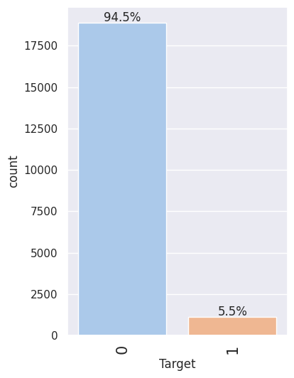

```python
# create a visual bar plot of the counts for the Target variable for class balances for training dataset
labeled_barplot(data, 'Target', perc=True)
plt.show()
```

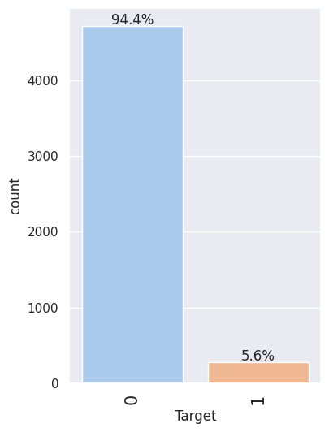

```python
# create a visual bar plot of the counts for the Target variable for class balances for test dataset
labeled_barplot(data_test, 'Target', perc=True)
plt.show()
```

Observations: The Target data for both datasets are heavily imbalanced.

- For the training dataset: 5.5% of the target variables “1” are considered as “failure” and 94.5% of the target variables “0” represent “No failure”.
- For test dataset: 5.6% of the target variables “1” are considered as “failure” and 94.4% of the target variables “0” represent “No failure”.

### Checking the Ciphered data for V-1 through V-40

- The data is confidential so this will be a generic look for skewness, outliers and any multimodal distributions (if any)

```python
# run the combined boxplot and histogram for V1-V40 features
for col in data.columns[:-1]:
    histogram_boxplot(data, col, kde=True, bins=30)
    plt.show()
```

[output not shown]

```
Output hidden; open in https://colab.research.google.com to view.
```

Observations:

- The majority of the graphs show that there is a symmetrical distribution but lots of outliers in both positive and negative ranges: V2, V3, V4, V5, V6, V7, V9, V11, V12, V13, V14, V15, V18, V20, V21, V23, V25, V28, V31, V32, V33, V36, V38, V39, V49
- There are also quite a few of the graphs that are right skewed in distribution (positive tail heavier than negative) with lots of outliers particularly strong in positive range: V1, V18, V22, V24, V27, V29, V35, V37
- There are also several graphs that are left skewed in distribution (negative tail heavier than positive) with lots of outliers particularly strong in negative range: V8, V10, V16, V19, V26, V30, V34

## Bivariate Analysis

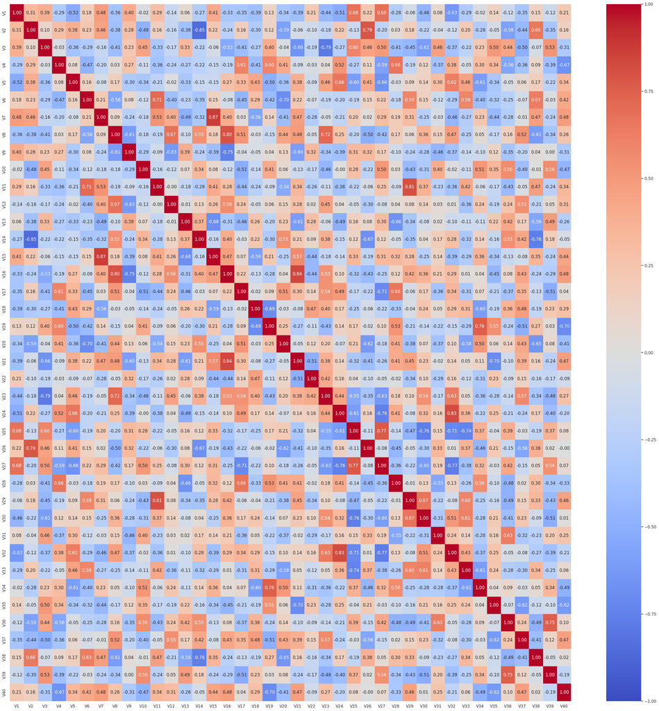

```python
# create a heatmap for the correlation of the numeric features
cols_list = data.select_dtypes(include=np.number).columns.tolist()
cols_list.remove('Target')
plt.figure(figsize=(35, 35))
sns.heatmap(
    data[cols_list].corr(),
    annot=True,
    vmin=-1, vmax=1,
    fmt=".2f",
    cmap='coolwarm'
)
plt.show()
```

High Negative Correlation:

- V2-V14 (-.85)
- V3-V23 (-.79)

# **Data Preprocessing**

### Splitting the Dataset

```python
# defining the dependent and independent variables for training dataset
X = data.drop(['Target'], axis=1)
y = data['Target']
```

```python
# splitting the data in 80:20 ratio for training and validation data
X_train, X_val, y_train, y_val = train_test_split(X, y, test_size=0.2,random_state=1, stratify=y)
```

```python
# defining the dependent and independent variables for test dataset
X_test = data_test.drop(['Target'], axis=1)
y_test = data_test['Target']
```

```python
print("Number of rows in train data =", X_train.shape[0])
print("Number of rows in validation data =", X_val.shape[0])
print("Number of rows in test data =", X_test.shape[0])
```

```
Number of rows in train data = 16000
Number of rows in validation data = 4000
Number of rows in test data = 5000
```

### Missing Value Imputation

```python
# missing values of V1 and V2 will be imputed with median
imputer = SimpleImputer(strategy='median')

# fit and transform the data to impute missing values while avoiding any data leakage
X_train = pd.DataFrame(imputer.fit_transform(X_train), columns=X_train.columns)
X_val = pd.DataFrame(imputer.transform(X_val), columns=X_train.columns)
X_test = pd.DataFrame(imputer.transform(X_test), columns=X_train.columns)
```

```python
# convert data labels into NumPy array format to use labels in correct shape so that training/validation/testing can be used safely without errors.
y_train = y_train.to_numpy()
y_val = y_val.to_numpy()
y_test = y_test.to_numpy()
```

```python
# check data for any records with no data entered for the column for training dataset
print(X_train.isnull().sum())
```

```
V1     0
V2     0
V3     0
V4     0
V5     0
V6     0
V7     0
V8     0
V9     0
V10    0
V11    0
V12    0
V13    0
V14    0
V15    0
V16    0
V17    0
V18    0
V19    0
V20    0
V21    0
V22    0
V23    0
V24    0
V25    0
V26    0
V27    0
V28    0
V29    0
V30    0
V31    0
V32    0
V33    0
V34    0
V35    0
V36    0
V37    0
V38    0
V39    0
V40    0
dtype: int64
```

```python
# check data for any records with no data entered for the column for validation dataset
print(X_val.isnull().sum())
```

```
V1     0
V2     0
V3     0
V4     0
V5     0
V6     0
V7     0
V8     0
V9     0
V10    0
V11    0
V12    0
V13    0
V14    0
V15    0
V16    0
V17    0
V18    0
V19    0
V20    0
V21    0
V22    0
V23    0
V24    0
V25    0
V26    0
V27    0
V28    0
V29    0
V30    0
V31    0
V32    0
V33    0
V34    0
V35    0
V36    0
V37    0
V38    0
V39    0
V40    0
dtype: int64
```

```python
# check data for any records with no data entered for the column for test dataset
print(X_test.isnull().sum())
```

```
V1     0
V2     0
V3     0
V4     0
V5     0
V6     0
V7     0
V8     0
V9     0
V10    0
V11    0
V12    0
V13    0
V14    0
V15    0
V16    0
V17    0
V18    0
V19    0
V20    0
V21    0
V22    0
V23    0
V24    0
V25    0
V26    0
V27    0
V28    0
V29    0
V30    0
V31    0
V32    0
V33    0
V34    0
V35    0
V36    0
V37    0
V38    0
V39    0
V40    0
dtype: int64
```

Observations: Imputed median values so now V1 and V2 on both training and test data sets are no longer missing.

# **Model Building**

```python
def plot(history, name):
    """
    Function to plot loss/accuracy

    history: an object which stores the metrics and losses.
    name: can be one of Loss or Accuracy
    """
    fig, ax = plt.subplots() #Creating a subplot with figure and axes.
    plt.plot(history.history[name]) #Plotting the train accuracy or train loss
    plt.plot(history.history['val_'+name]) #Plotting the validation accuracy or validation loss

    plt.title('Model ' + name.capitalize()) #Defining the title of the plot.
    plt.ylabel(name.capitalize()) #Capitalizing the first letter.
    plt.xlabel('Epoch') #Defining the label for the x-axis.
    fig.legend(['Train', 'Validation'], loc="outside right upper") #Defining the legend, loc controls the position of the legend.
```

```python
#Defining the columns of the dataframe which are nothing but the hyper parameters and the metrics.
columns = ["# hidden layers","# neurons - hidden layer","activation function - hidden layer ","# epochs","batch size","optimizer","learning rate, momentum","weight initializer","regularization","train loss","validation loss","train accuracy","validation accuracy","time (secs)"]

#Creating a pandas dataframe.
results = pd.DataFrame(columns=columns)
```

```python
# defining a function to compute different metrics to check performance of a classification model built using statsmodels
def model_performance_classification(
    model, predictors, target, threshold=0.5
):
    """
    Function to compute different metrics to check classification model performance

    model: classifier
    predictors: independent variables
    target: dependent variable
    threshold: threshold for classifying the observation as class 1
    """

    # checking which probabilities are greater than threshold
    pred = model.predict(predictors) > threshold
    # pred_temp = model.predict(predictors) > threshold
    # # rounding off the above values to get classes
    # pred = np.round(pred_temp)

    acc = accuracy_score(target, pred)  # to compute Accuracy
    recall = recall_score(target, pred, average='weighted')  # to compute Recall
    precision = precision_score(target, pred, average='weighted')  # to compute Precision
    f1 = f1_score(target, pred, average='weighted')  # to compute F1-score

    # creating a dataframe of metrics
    df_perf = pd.DataFrame(
        {"Accuracy": acc, "Recall": recall, "Precision": precision, "F1 Score": f1,},
        index=[0],
    )

    return df_perf
```

## Model Evaluation Criterion

Write down the model evaluation criterion with rationale

The business objective to build a classification model that best identifies failures in generators that can be repaired before failing/breaking to reduce the overall maintenance costs.

- True positives (TP) are the detected failures which are repair costs which are less than the cost of replacing the generator. These costs are acceptable.
- False positives (FP) are detections where there is no failure which are inspection costs and less cost than repair costs. These are the least costly.
- False negatives (FN) are the undetected failures which results in a replacement cost which is the most expensive and most unacceptable cost.

**So we must prioritize minimizing the false negatives (cost-sensitive classification) which aligns with the Recall metric. So we will use Recall (Class1) = TP / (TP + FN) in our model building. Missing a failure (FN) is far more expensive than over predicting a failure (FP). Recall will provide us a score of how many actual failures we are catching which the higher the Recall score the better.**

```python
# y_train is your training labels
cw = (len(y_train)) / (np.bincount(y_train) * 2)

# Convert into dictionary {class: weight}
cw_dict = {i : cw[i] for i in range(len(cw))}
print(cw_dict)
```

```
{0: np.float64(0.5293806246691372), 1: np.float64(9.00900900900901)}
```

Observations: Class 0 is down-weighted at 0.53 while the Class 1 is up-weighted at 9.0. This class weight will help ensure the model is paying attention to the failures.

```python
batch_size = 64
epochs = 50
```

Observations: Using batch size of 64 for efficiency purposes and help escape local minima. Using epochs of 50 allows the model to converge and it is a good starting point generally.

## Initial Model Building (Model 0)

We will use the following hyperparamters for these models:

- ReLu activation function for Hidden layers to ensure we introducing non-linearity into the model.
- Sigmoid activation function for Output layer in order to predict the probablity of failure where our classes are 1 = failure and 0 = no failure. This function is perfect for binary classification like this effort.
- Binary crossentropy loss function will penalize the wrong predictions which aligns with the goal of this effort.
- Let's start with a neural network consisting of
  - just one hidden layer of 64 units to learn general patterns
  - activation function of ReLU to learn nonlinear features efficiently
  - SGD as the optimizer to update model's weights one batch at a time
  - Sigmoid output which is useful for binary classification

```python
# clears the current Keras session, resetting all layers and models previously created, freeing up memory and resources.
tf.keras.backend.clear_session()
```

```python
# initializing the neural network with one hidden layer and activation function of ReLU
model0 = Sequential()
model0.add(Dense(64, activation = 'relu', input_dim = X_train.shape[1]))
model0.add(Dense(1, activation='sigmoid'))
```

```python
# printing the summary
model0.summary()
```

```
Model: "sequential"
```

```
┏━━━━━━━━━━━━━━━━━━━━━━━━━━━━━━━━━┳━━━━━━━━━━━━━━━━━━━━━━━━┳━━━━━━━━━━━━━━━┓
┃ Layer (type)                    ┃ Output Shape           ┃       Param # ┃
┡━━━━━━━━━━━━━━━━━━━━━━━━━━━━━━━━━╇━━━━━━━━━━━━━━━━━━━━━━━━╇━━━━━━━━━━━━━━━┩
│ dense (Dense)                   │ (None, 64)             │         2,624 │
├─────────────────────────────────┼────────────────────────┼───────────────┤
│ dense_1 (Dense)                 │ (None, 1)              │            65 │
└─────────────────────────────────┴────────────────────────┴───────────────┘
```

```
 Total params: 2,689 (10.50 KB)
```

```
 Trainable params: 2,689 (10.50 KB)
```

```
 Non-trainable params: 0 (0.00 B)
```

```python
# compile the model
# define the optimizer using SGD
optimizer = keras.optimizers.SGD()
model0.compile(
    loss='binary_crossentropy',
    optimizer=optimizer,
    metrics=[Recall()]
)
```

```python
# time.time() returns the time in seconds
start = time.time()
# Fitting the model.
history = model0.fit(X_train, y_train, validation_data=(X_val,y_val) , batch_size=batch_size, epochs=epochs)
# time.time() returns the time in seconds
end=time.time()
```

```
250/250 ━━━━━━━━━━━━━━━━━━━━ 1s 3ms/step - loss: 0.2776 - recall: 0.3663 - val_loss: 0.1126 - val_recall: 0.5676
250/250 ━━━━━━━━━━━━━━━━━━━━ 1s 2ms/step - loss: 0.0991 - recall: 0.5734 - val_loss: 0.0976 - val_recall: 0.6937
250/250 ━━━━━━━━━━━━━━━━━━━━ 1s 3ms/step - loss: 0.0843 - recall: 0.6430 - val_loss: 0.0907 - val_recall: 0.7072
250/250 ━━━━━━━━━━━━━━━━━━━━ 1s 4ms/step - loss: 0.0765 - recall: 0.6940 - val_loss: 0.0860 - val_recall: 0.7342
250/250 ━━━━━━━━━━━━━━━━━━━━ 1s 3ms/step - loss: 0.0713 - recall: 0.7279 - val_loss: 0.0825 - val_recall: 0.7432
250/250 ━━━━━━━━━━━━━━━━━━━━ 1s 2ms/step - loss: 0.0674 - recall: 0.7596 - val_loss: 0.0798 - val_recall: 0.7658
250/250 ━━━━━━━━━━━━━━━━━━━━ 1s 2ms/step - loss: 0.0644 - recall: 0.7715 - val_loss: 0.0775 - val_recall: 0.7748
250/250 ━━━━━━━━━━━━━━━━━━━━ 1s 2ms/step - loss: 0.0620 - recall: 0.7853 - val_loss: 0.0756 - val_recall: 0.7838
250/250 ━━━━━━━━━━━━━━━━━━━━ 1s 2ms/step - loss: 0.0600 - recall: 0.7937 - val_loss: 0.0741 - val_recall: 0.7793
250/250 ━━━━━━━━━━━━━━━━━━━━ 1s 2ms/step - loss: 0.0584 - recall: 0.8008 - val_loss: 0.0729 - val_recall: 0.7838
250/250 ━━━━━━━━━━━━━━━━━━━━ 1s 2ms/step - loss: 0.0570 - recall: 0.8048 - val_loss: 0.0718 - val_recall: 0.7838
250/250 ━━━━━━━━━━━━━━━━━━━━ 1s 2ms/step - loss: 0.0557 - recall: 0.8094 - val_loss: 0.0710 - val_recall: 0.7883
250/250 ━━━━━━━━━━━━━━━━━━━━ 1s 3ms/step - loss: 0.0546 - recall: 0.8178 - val_loss: 0.0702 - val_recall: 0.7928
250/250 ━━━━━━━━━━━━━━━━━━━━ 1s 2ms/step - loss: 0.0537 - recall: 0.8247 - val_loss: 0.0696 - val_recall: 0.7973
250/250 ━━━━━━━━━━━━━━━━━━━━ 1s 2ms/step - loss: 0.0528 - recall: 0.8257 - val_loss: 0.0690 - val_recall: 0.7973
250/250 ━━━━━━━━━━━━━━━━━━━━ 1s 2ms/step - loss: 0.0520 - recall: 0.8311 - val_loss: 0.0685 - val_recall: 0.8018
250/250 ━━━━━━━━━━━━━━━━━━━━ 1s 2ms/step - loss: 0.0513 - recall: 0.8328 - val_loss: 0.0681 - val_recall: 0.8018
250/250 ━━━━━━━━━━━━━━━━━━━━ 1s 2ms/step - loss: 0.0506 - recall: 0.8356 - val_loss: 0.0677 - val_recall: 0.8018
250/250 ━━━━━━━━━━━━━━━━━━━━ 1s 2ms/step - loss: 0.0500 - recall: 0.8356 - val_loss: 0.0673 - val_recall: 0.8018
250/250 ━━━━━━━━━━━━━━━━━━━━ 1s 2ms/step - loss: 0.0495 - recall: 0.8366 - val_loss: 0.0670 - val_recall: 0.8018
250/250 ━━━━━━━━━━━━━━━━━━━━ 1s 4ms/step - loss: 0.0490 - recall: 0.8382 - val_loss: 0.0667 - val_recall: 0.8018
250/250 ━━━━━━━━━━━━━━━━━━━━ 1s 4ms/step - loss: 0.0485 - recall: 0.8390 - val_loss: 0.0664 - val_recall: 0.8063
250/250 ━━━━━━━━━━━━━━━━━━━━ 1s 3ms/step - loss: 0.0480 - recall: 0.8391 - val_loss: 0.0662 - val_recall: 0.8108
250/250 ━━━━━━━━━━━━━━━━━━━━ 1s 2ms/step - loss: 0.0476 - recall: 0.8391 - val_loss: 0.0659 - val_recall: 0.8063
250/250 ━━━━━━━━━━━━━━━━━━━━ 1s 2ms/step - loss: 0.0472 - recall: 0.8419 - val_loss: 0.0657 - val_recall: 0.8108
250/250 ━━━━━━━━━━━━━━━━━━━━ 1s 2ms/step - loss: 0.0468 - recall: 0.8459 - val_loss: 0.0655 - val_recall: 0.8063
250/250 ━━━━━━━━━━━━━━━━━━━━ 1s 2ms/step - loss: 0.0465 - recall: 0.8475 - val_loss: 0.0653 - val_recall: 0.8063
250/250 ━━━━━━━━━━━━━━━━━━━━ 1s 2ms/step - loss: 0.0462 - recall: 0.8468 - val_loss: 0.0652 - val_recall: 0.8063
250/250 ━━━━━━━━━━━━━━━━━━━━ 1s 2ms/step - loss: 0.0458 - recall: 0.8522 - val_loss: 0.0650 - val_recall: 0.8108
250/250 ━━━━━━━━━━━━━━━━━━━━ 1s 2ms/step - loss: 0.0455 - recall: 0.8518 - val_loss: 0.0649 - val_recall: 0.8153
250/250 ━━━━━━━━━━━━━━━━━━━━ 1s 2ms/step - loss: 0.0453 - recall: 0.8518 - val_loss: 0.0647 - val_recall: 0.8288
250/250 ━━━━━━━━━━━━━━━━━━━━ 1s 2ms/step - loss: 0.0450 - recall: 0.8518 - val_loss: 0.0646 - val_recall: 0.8243
250/250 ━━━━━━━━━━━━━━━━━━━━ 1s 2ms/step - loss: 0.0447 - recall: 0.8518 - val_loss: 0.0645 - val_recall: 0.8243
250/250 ━━━━━━━━━━━━━━━━━━━━ 1s 2ms/step - loss: 0.0444 - recall: 0.8518 - val_loss: 0.0644 - val_recall: 0.8243
250/250 ━━━━━━━━━━━━━━━━━━━━ 1s 2ms/step - loss: 0.0442 - recall: 0.8559 - val_loss: 0.0643 - val_recall: 0.8288
250/250 ━━━━━━━━━━━━━━━━━━━━ 1s 2ms/step - loss: 0.0440 - recall: 0.8591 - val_loss: 0.0642 - val_recall: 0.8378
250/250 ━━━━━━━━━━━━━━━━━━━━ 1s 2ms/step - loss: 0.0437 - recall: 0.8595 - val_loss: 0.0642 - val_recall: 0.8378
250/250 ━━━━━━━━━━━━━━━━━━━━ 1s 2ms/step - loss: 0.0435 - recall: 0.8645 - val_loss: 0.0641 - val_recall: 0.8378
250/250 ━━━━━━━━━━━━━━━━━━━━ 1s 3ms/step - loss: 0.0433 - recall: 0.8643 - val_loss: 0.0640 - val_recall: 0.8378
250/250 ━━━━━━━━━━━━━━━━━━━━ 1s 4ms/step - loss: 0.0431 - recall: 0.8679 - val_loss: 0.0640 - val_recall: 0.8423
250/250 ━━━━━━━━━━━━━━━━━━━━ 1s 4ms/step - loss: 0.0429 - recall: 0.8698 - val_loss: 0.0639 - val_recall: 0.8423
250/250 ━━━━━━━━━━━━━━━━━━━━ 1s 2ms/step - loss: 0.0427 - recall: 0.8696 - val_loss: 0.0638 - val_recall: 0.8423
250/250 ━━━━━━━━━━━━━━━━━━━━ 1s 2ms/step - loss: 0.0425 - recall: 0.8710 - val_loss: 0.0638 - val_recall: 0.8468
250/250 ━━━━━━━━━━━━━━━━━━━━ 1s 2ms/step - loss: 0.0423 - recall: 0.8719 - val_loss: 0.0638 - val_recall: 0.8468
250/250 ━━━━━━━━━━━━━━━━━━━━ 1s 2ms/step - loss: 0.0421 - recall: 0.8719 - val_loss: 0.0637 - val_recall: 0.8468
250/250 ━━━━━━━━━━━━━━━━━━━━ 1s 2ms/step - loss: 0.0419 - recall: 0.8719 - val_loss: 0.0637 - val_recall: 0.8468
250/250 ━━━━━━━━━━━━━━━━━━━━ 1s 2ms/step - loss: 0.0418 - recall: 0.8719 - val_loss: 0.0636 - val_recall: 0.8468
250/250 ━━━━━━━━━━━━━━━━━━━━ 1s 2ms/step - loss: 0.0416 - recall: 0.8723 - val_loss: 0.0636 - val_recall: 0.8468
250/250 ━━━━━━━━━━━━━━━━━━━━ 1s 2ms/step - loss: 0.0414 - recall: 0.8723 - val_loss: 0.0635 - val_recall: 0.8468
250/250 ━━━━━━━━━━━━━━━━━━━━ 1s 2ms/step - loss: 0.0413 - recall: 0.8719 - val_loss: 0.0635 - val_recall: 0.8468
```

```python
print("Time taken in seconds ",end-start)
```

```
Time taken in seconds  37.12257695198059
```

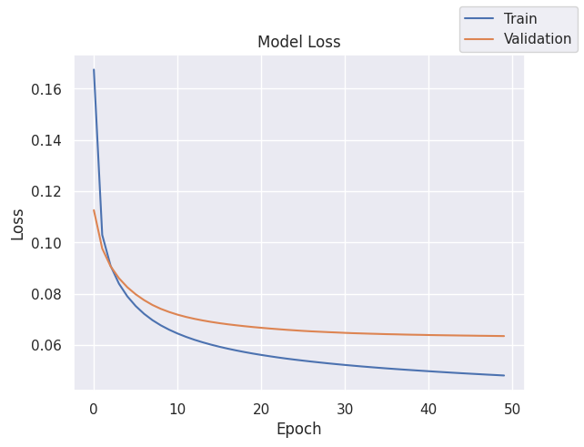

```python
plot(history,'loss')
```

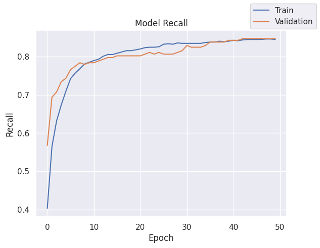

```python
plot(history,'recall')
```

```python
model0_train_perf = model_performance_classification(model0, X_train, y_train)
model0_train_perf
```

```
500/500 ━━━━━━━━━━━━━━━━━━━━ 1s 993us/step
```

|  | Accuracy | Recall | Precision | F1 Score |
| --- | --- | --- | --- | --- |
| 0 | 0.990625 | 0.990625 | 0.990537 | 0.99031 |

```python
model0_val_perf = model_performance_classification(model0, X_val, y_val)
model0_val_perf
```

```
125/125 ━━━━━━━━━━━━━━━━━━━━ 0s 1ms/step
```

|  | Accuracy | Recall | Precision | F1 Score |
| --- | --- | --- | --- | --- |
| 0 | 0.99025 | 0.99025 | 0.990127 | 0.989928 |

Observations:

- Recall scores suggest that it is generalizing well.
- Training and validation scores are almost identical which suggests that the model is not overfitting
- Metrics are very high so there could be a concern with dataset imbalanced

# **Model Performance Improvement**

## Model 1

- Added an additional hidden layer of 32 with a neural network consisting of
  - one hidden layer of 64 units to learn general patterns
  - activation function of ReLU to learn nonlinear features efficiently
  - SGD as the optimizer with learning rate and momementum to update model's weights one batch at a time
  - Sigmoid output which is useful for binary classification

```python
# clears the current Keras session, resetting all layers and models previously created, freeing up memory and resources.
tf.keras.backend.clear_session()
```

```python
# initializing the neural network with one hidden layer and activation function of ReLU
model1 = Sequential()
model1.add(Dense(64, activation = 'relu', input_dim = X_train.shape[1]))
model1.add(Dense(32, activation= 'relu'))
model1.add(Dense(1, activation='sigmoid'))
```

```python
# printing the summary
model1.summary()
```

```
Model: "sequential"
```

```
┏━━━━━━━━━━━━━━━━━━━━━━━━━━━━━━━━━┳━━━━━━━━━━━━━━━━━━━━━━━━┳━━━━━━━━━━━━━━━┓
┃ Layer (type)                    ┃ Output Shape           ┃       Param # ┃
┡━━━━━━━━━━━━━━━━━━━━━━━━━━━━━━━━━╇━━━━━━━━━━━━━━━━━━━━━━━━╇━━━━━━━━━━━━━━━┩
│ dense (Dense)                   │ (None, 64)             │         2,624 │
├─────────────────────────────────┼────────────────────────┼───────────────┤
│ dense_1 (Dense)                 │ (None, 32)             │         2,080 │
├─────────────────────────────────┼────────────────────────┼───────────────┤
│ dense_2 (Dense)                 │ (None, 1)              │            33 │
└─────────────────────────────────┴────────────────────────┴───────────────┘
```

```
 Total params: 4,737 (18.50 KB)
```

```
 Trainable params: 4,737 (18.50 KB)
```

```
 Non-trainable params: 0 (0.00 B)
```

```python
# compile the model
# define the optimizer using SGD
optimizer = keras.optimizers.SGD(learning_rate=0.01, momentum=0.9)
model1.compile(
    loss='binary_crossentropy',
    optimizer=optimizer,
    metrics=[Recall()]
)
```

```python
# time.time() returns the time in seconds
start = time.time()
# Fitting the model.
history = model1.fit(X_train, y_train, validation_data=(X_val,y_val) , batch_size=batch_size, epochs=epochs)
# time.time() returns the time in seconds
end=time.time()
```

```
250/250 ━━━━━━━━━━━━━━━━━━━━ 6s 8ms/step - loss: 0.1775 - recall: 0.4708 - val_loss: 0.0777 - val_recall: 0.7928
250/250 ━━━━━━━━━━━━━━━━━━━━ 1s 5ms/step - loss: 0.0591 - recall: 0.8039 - val_loss: 0.0689 - val_recall: 0.8423
250/250 ━━━━━━━━━━━━━━━━━━━━ 1s 4ms/step - loss: 0.0500 - recall: 0.8289 - val_loss: 0.0652 - val_recall: 0.8423
250/250 ━━━━━━━━━━━━━━━━━━━━ 1s 5ms/step - loss: 0.0452 - recall: 0.8512 - val_loss: 0.0633 - val_recall: 0.8378
250/250 ━━━━━━━━━━━━━━━━━━━━ 1s 5ms/step - loss: 0.0419 - recall: 0.8677 - val_loss: 0.0623 - val_recall: 0.8423
250/250 ━━━━━━━━━━━━━━━━━━━━ 2s 2ms/step - loss: 0.0393 - recall: 0.8749 - val_loss: 0.0615 - val_recall: 0.8514
250/250 ━━━━━━━━━━━━━━━━━━━━ 1s 2ms/step - loss: 0.0375 - recall: 0.8812 - val_loss: 0.0606 - val_recall: 0.8468
250/250 ━━━━━━━━━━━━━━━━━━━━ 1s 3ms/step - loss: 0.0359 - recall: 0.8882 - val_loss: 0.0604 - val_recall: 0.8468
250/250 ━━━━━━━━━━━━━━━━━━━━ 1s 3ms/step - loss: 0.0345 - recall: 0.8940 - val_loss: 0.0605 - val_recall: 0.8468
250/250 ━━━━━━━━━━━━━━━━━━━━ 1s 4ms/step - loss: 0.0331 - recall: 0.8973 - val_loss: 0.0603 - val_recall: 0.8468
250/250 ━━━━━━━━━━━━━━━━━━━━ 1s 4ms/step - loss: 0.0319 - recall: 0.9001 - val_loss: 0.0601 - val_recall: 0.8468
250/250 ━━━━━━━━━━━━━━━━━━━━ 1s 2ms/step - loss: 0.0308 - recall: 0.9047 - val_loss: 0.0603 - val_recall: 0.8514
250/250 ━━━━━━━━━━━━━━━━━━━━ 1s 2ms/step - loss: 0.0301 - recall: 0.9106 - val_loss: 0.0604 - val_recall: 0.8514
250/250 ━━━━━━━━━━━━━━━━━━━━ 1s 2ms/step - loss: 0.0293 - recall: 0.9134 - val_loss: 0.0605 - val_recall: 0.8559
250/250 ━━━━━━━━━━━━━━━━━━━━ 1s 2ms/step - loss: 0.0287 - recall: 0.9124 - val_loss: 0.0606 - val_recall: 0.8604
250/250 ━━━━━━━━━━━━━━━━━━━━ 1s 2ms/step - loss: 0.0281 - recall: 0.9121 - val_loss: 0.0610 - val_recall: 0.8604
250/250 ━━━━━━━━━━━━━━━━━━━━ 1s 2ms/step - loss: 0.0274 - recall: 0.9139 - val_loss: 0.0611 - val_recall: 0.8604
250/250 ━━━━━━━━━━━━━━━━━━━━ 1s 2ms/step - loss: 0.0270 - recall: 0.9151 - val_loss: 0.0622 - val_recall: 0.8604
250/250 ━━━━━━━━━━━━━━━━━━━━ 1s 2ms/step - loss: 0.0267 - recall: 0.9163 - val_loss: 0.0625 - val_recall: 0.8604
250/250 ━━━━━━━━━━━━━━━━━━━━ 1s 2ms/step - loss: 0.0262 - recall: 0.9168 - val_loss: 0.0636 - val_recall: 0.8694
250/250 ━━━━━━━━━━━━━━━━━━━━ 1s 2ms/step - loss: 0.0259 - recall: 0.9163 - val_loss: 0.0641 - val_recall: 0.8694
250/250 ━━━━━━━━━━━━━━━━━━━━ 1s 2ms/step - loss: 0.0256 - recall: 0.9172 - val_loss: 0.0647 - val_recall: 0.8739
250/250 ━━━━━━━━━━━━━━━━━━━━ 1s 2ms/step - loss: 0.0254 - recall: 0.9169 - val_loss: 0.0645 - val_recall: 0.8739
250/250 ━━━━━━━━━━━━━━━━━━━━ 1s 2ms/step - loss: 0.0249 - recall: 0.9190 - val_loss: 0.0653 - val_recall: 0.8739
250/250 ━━━━━━━━━━━━━━━━━━━━ 1s 4ms/step - loss: 0.0246 - recall: 0.9169 - val_loss: 0.0666 - val_recall: 0.8739
250/250 ━━━━━━━━━━━━━━━━━━━━ 1s 4ms/step - loss: 0.0244 - recall: 0.9187 - val_loss: 0.0666 - val_recall: 0.8739
250/250 ━━━━━━━━━━━━━━━━━━━━ 1s 4ms/step - loss: 0.0242 - recall: 0.9186 - val_loss: 0.0669 - val_recall: 0.8739
250/250 ━━━━━━━━━━━━━━━━━━━━ 1s 2ms/step - loss: 0.0238 - recall: 0.9184 - val_loss: 0.0675 - val_recall: 0.8739
250/250 ━━━━━━━━━━━━━━━━━━━━ 1s 2ms/step - loss: 0.0236 - recall: 0.9195 - val_loss: 0.0681 - val_recall: 0.8784
250/250 ━━━━━━━━━━━━━━━━━━━━ 1s 2ms/step - loss: 0.0232 - recall: 0.9186 - val_loss: 0.0690 - val_recall: 0.8739
250/250 ━━━━━━━━━━━━━━━━━━━━ 1s 2ms/step - loss: 0.0229 - recall: 0.9239 - val_loss: 0.0696 - val_recall: 0.8784
250/250 ━━━━━━━━━━━━━━━━━━━━ 1s 2ms/step - loss: 0.0226 - recall: 0.9239 - val_loss: 0.0703 - val_recall: 0.8739
250/250 ━━━━━━━━━━━━━━━━━━━━ 1s 2ms/step - loss: 0.0223 - recall: 0.9243 - val_loss: 0.0706 - val_recall: 0.8784
250/250 ━━━━━━━━━━━━━━━━━━━━ 1s 2ms/step - loss: 0.0220 - recall: 0.9259 - val_loss: 0.0712 - val_recall: 0.8739
250/250 ━━━━━━━━━━━━━━━━━━━━ 1s 2ms/step - loss: 0.0219 - recall: 0.9222 - val_loss: 0.0715 - val_recall: 0.8739
250/250 ━━━━━━━━━━━━━━━━━━━━ 1s 2ms/step - loss: 0.0214 - recall: 0.9267 - val_loss: 0.0726 - val_recall: 0.8739
250/250 ━━━━━━━━━━━━━━━━━━━━ 1s 2ms/step - loss: 0.0211 - recall: 0.9222 - val_loss: 0.0720 - val_recall: 0.8739
250/250 ━━━━━━━━━━━━━━━━━━━━ 1s 2ms/step - loss: 0.0209 - recall: 0.9269 - val_loss: 0.0739 - val_recall: 0.8739
250/250 ━━━━━━━━━━━━━━━━━━━━ 1s 2ms/step - loss: 0.0207 - recall: 0.9270 - val_loss: 0.0736 - val_recall: 0.8739
250/250 ━━━━━━━━━━━━━━━━━━━━ 1s 2ms/step - loss: 0.0205 - recall: 0.9268 - val_loss: 0.0748 - val_recall: 0.8739
250/250 ━━━━━━━━━━━━━━━━━━━━ 1s 2ms/step - loss: 0.0204 - recall: 0.9222 - val_loss: 0.0748 - val_recall: 0.8739
250/250 ━━━━━━━━━━━━━━━━━━━━ 1s 2ms/step - loss: 0.0200 - recall: 0.9255 - val_loss: 0.0758 - val_recall: 0.8784
250/250 ━━━━━━━━━━━━━━━━━━━━ 1s 4ms/step - loss: 0.0199 - recall: 0.9253 - val_loss: 0.0774 - val_recall: 0.8739
250/250 ━━━━━━━━━━━━━━━━━━━━ 1s 4ms/step - loss: 0.0198 - recall: 0.9276 - val_loss: 0.0769 - val_recall: 0.8784
250/250 ━━━━━━━━━━━━━━━━━━━━ 1s 4ms/step - loss: 0.0196 - recall: 0.9274 - val_loss: 0.0774 - val_recall: 0.8739
250/250 ━━━━━━━━━━━━━━━━━━━━ 1s 2ms/step - loss: 0.0192 - recall: 0.9275 - val_loss: 0.0785 - val_recall: 0.8784
250/250 ━━━━━━━━━━━━━━━━━━━━ 1s 2ms/step - loss: 0.0190 - recall: 0.9272 - val_loss: 0.0779 - val_recall: 0.8739
250/250 ━━━━━━━━━━━━━━━━━━━━ 1s 2ms/step - loss: 0.0185 - recall: 0.9276 - val_loss: 0.0805 - val_recall: 0.8784
250/250 ━━━━━━━━━━━━━━━━━━━━ 1s 2ms/step - loss: 0.0190 - recall: 0.9266 - val_loss: 0.0808 - val_recall: 0.8784
250/250 ━━━━━━━━━━━━━━━━━━━━ 1s 2ms/step - loss: 0.0186 - recall: 0.9279 - val_loss: 0.0807 - val_recall: 0.8784
```

```python
print("Time taken in seconds ",end-start)
```

```
Time taken in seconds  47.5143301486969
```

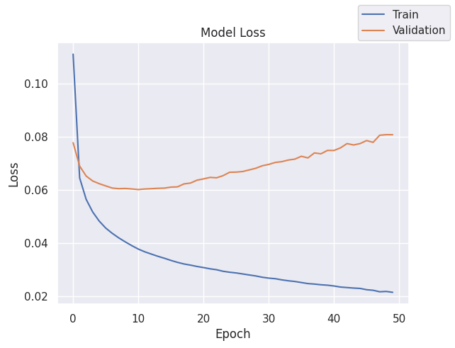

```python
plot(history,'loss')
```

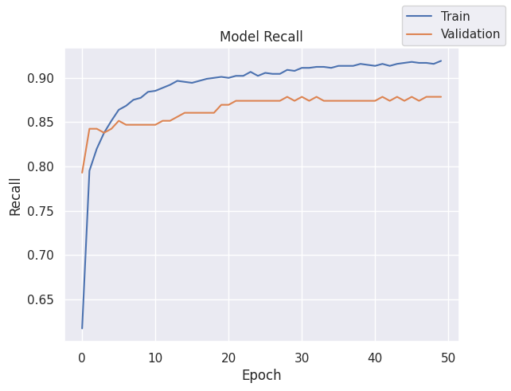

```python
plot(history,'recall')
```

```python
model1_train_perf = model_performance_classification(model1, X_train, y_train)
model1_train_perf
```

```
500/500 ━━━━━━━━━━━━━━━━━━━━ 1s 969us/step
```

|  | Accuracy | Recall | Precision | F1 Score |
| --- | --- | --- | --- | --- |
| 0 | 0.993938 | 0.993938 | 0.993876 | 0.993893 |

```python
model1_val_perf = model_performance_classification(model1, X_val, y_val)
model1_val_perf
```

```
125/125 ━━━━━━━━━━━━━━━━━━━━ 0s 2ms/step
```

|  | Accuracy | Recall | Precision | F1 Score |
| --- | --- | --- | --- | --- |
| 0 | 0.98925 | 0.98925 | 0.989061 | 0.989121 |

Observations:

- Training score for Recall is higher than Model 0
- Validation score for Recall is lower than Model 0
- Does not generalize as well as Model 0

## Model 2

- Changed SGD optimizer to Adam optimizer with learning rate to introduce momentum along with adaptive learning rate
  - one hidden layer of 64 units to learn general patterns
  - one hidden layer of 32 units to learn general patterns
  - activation function of ReLU to learn nonlinear features efficiently
  - Sigmoid output which is useful for binary classification
  - added class weight

```python
# clears the current Keras session, resetting all layers and models previously created, freeing up memory and resources.
tf.keras.backend.clear_session()
```

```python
# initializing the neural network with one hidden layer and activation function of ReLU
model2 = Sequential()
model2.add(Dense(64, activation = 'relu', input_dim = X_train.shape[1]))
model2.add(Dense(32, activation= 'relu'))
model2.add(Dense(1, activation='sigmoid'))
```

```python
# printing the summary
model2.summary()
```

```
Model: "sequential"
```

```
┏━━━━━━━━━━━━━━━━━━━━━━━━━━━━━━━━━┳━━━━━━━━━━━━━━━━━━━━━━━━┳━━━━━━━━━━━━━━━┓
┃ Layer (type)                    ┃ Output Shape           ┃       Param # ┃
┡━━━━━━━━━━━━━━━━━━━━━━━━━━━━━━━━━╇━━━━━━━━━━━━━━━━━━━━━━━━╇━━━━━━━━━━━━━━━┩
│ dense (Dense)                   │ (None, 64)             │         2,624 │
├─────────────────────────────────┼────────────────────────┼───────────────┤
│ dense_1 (Dense)                 │ (None, 32)             │         2,080 │
├─────────────────────────────────┼────────────────────────┼───────────────┤
│ dense_2 (Dense)                 │ (None, 1)              │            33 │
└─────────────────────────────────┴────────────────────────┴───────────────┘
```

```
 Total params: 4,737 (18.50 KB)
```

```
 Trainable params: 4,737 (18.50 KB)
```

```
 Non-trainable params: 0 (0.00 B)
```

```python
# compile the model
# define the optimizer using Adam
optimizer = keras.optimizers.Adam(learning_rate=0.01)
model2.compile(
    loss='binary_crossentropy',
    optimizer=optimizer,
    metrics=[Recall()]
)
```

```python
# time.time() returns the time in seconds
start = time.time()
# Fitting the model.
history = model2.fit(X_train, y_train, validation_data=(X_val,y_val) , batch_size=batch_size, epochs=epochs, class_weight=cw_dict)
# time.time() returns the time in seconds
end=time.time()
```

```
250/250 ━━━━━━━━━━━━━━━━━━━━ 2s 3ms/step - loss: 0.3674 - recall: 0.8137 - val_loss: 0.2557 - val_recall: 0.8919
250/250 ━━━━━━━━━━━━━━━━━━━━ 1s 2ms/step - loss: 0.1998 - recall: 0.9113 - val_loss: 0.2320 - val_recall: 0.8874
250/250 ━━━━━━━━━━━━━━━━━━━━ 1s 2ms/step - loss: 0.1893 - recall: 0.9085 - val_loss: 0.2025 - val_recall: 0.8874
250/250 ━━━━━━━━━━━━━━━━━━━━ 1s 2ms/step - loss: 0.1792 - recall: 0.9053 - val_loss: 0.2329 - val_recall: 0.8919
250/250 ━━━━━━━━━━━━━━━━━━━━ 1s 2ms/step - loss: 0.1549 - recall: 0.9167 - val_loss: 0.1663 - val_recall: 0.8964
250/250 ━━━━━━━━━━━━━━━━━━━━ 1s 2ms/step - loss: 0.1549 - recall: 0.9186 - val_loss: 0.2084 - val_recall: 0.8829
250/250 ━━━━━━━━━━━━━━━━━━━━ 1s 2ms/step - loss: 0.1465 - recall: 0.9238 - val_loss: 0.1643 - val_recall: 0.8964
250/250 ━━━━━━━━━━━━━━━━━━━━ 1s 2ms/step - loss: 0.1466 - recall: 0.9221 - val_loss: 0.1466 - val_recall: 0.8784
250/250 ━━━━━━━━━━━━━━━━━━━━ 1s 2ms/step - loss: 0.1546 - recall: 0.9191 - val_loss: 0.1738 - val_recall: 0.8874
250/250 ━━━━━━━━━━━━━━━━━━━━ 2s 4ms/step - loss: 0.1480 - recall: 0.9234 - val_loss: 0.1520 - val_recall: 0.8739
250/250 ━━━━━━━━━━━━━━━━━━━━ 1s 4ms/step - loss: 0.1308 - recall: 0.9285 - val_loss: 0.1337 - val_recall: 0.8784
250/250 ━━━━━━━━━━━━━━━━━━━━ 1s 3ms/step - loss: 0.1268 - recall: 0.9297 - val_loss: 0.1363 - val_recall: 0.8694
250/250 ━━━━━━━━━━━━━━━━━━━━ 1s 3ms/step - loss: 0.1425 - recall: 0.9268 - val_loss: 0.1666 - val_recall: 0.8874
250/250 ━━━━━━━━━━━━━━━━━━━━ 1s 2ms/step - loss: 0.1365 - recall: 0.9272 - val_loss: 0.1436 - val_recall: 0.8739
250/250 ━━━━━━━━━━━━━━━━━━━━ 1s 2ms/step - loss: 0.1225 - recall: 0.9338 - val_loss: 0.1394 - val_recall: 0.8784
250/250 ━━━━━━━━━━━━━━━━━━━━ 1s 2ms/step - loss: 0.1211 - recall: 0.9345 - val_loss: 0.1532 - val_recall: 0.8919
250/250 ━━━━━━━━━━━━━━━━━━━━ 1s 2ms/step - loss: 0.1432 - recall: 0.9261 - val_loss: 0.1610 - val_recall: 0.8784
250/250 ━━━━━━━━━━━━━━━━━━━━ 1s 3ms/step - loss: 0.1359 - recall: 0.9246 - val_loss: 0.1398 - val_recall: 0.8784
250/250 ━━━━━━━━━━━━━━━━━━━━ 1s 2ms/step - loss: 0.1302 - recall: 0.9314 - val_loss: 0.2069 - val_recall: 0.9009
250/250 ━━━━━━━━━━━━━━━━━━━━ 1s 2ms/step - loss: 0.1336 - recall: 0.9312 - val_loss: 0.1512 - val_recall: 0.9009
250/250 ━━━━━━━━━━━━━━━━━━━━ 1s 2ms/step - loss: 0.1288 - recall: 0.9327 - val_loss: 0.1650 - val_recall: 0.8874
250/250 ━━━━━━━━━━━━━━━━━━━━ 1s 2ms/step - loss: 0.1242 - recall: 0.9305 - val_loss: 0.3128 - val_recall: 0.8964
250/250 ━━━━━━━━━━━━━━━━━━━━ 1s 2ms/step - loss: 0.1358 - recall: 0.9286 - val_loss: 0.1727 - val_recall: 0.8739
250/250 ━━━━━━━━━━━━━━━━━━━━ 1s 2ms/step - loss: 0.1262 - recall: 0.9320 - val_loss: 0.1779 - val_recall: 0.8964
250/250 ━━━━━━━━━━━━━━━━━━━━ 1s 3ms/step - loss: 0.1378 - recall: 0.9265 - val_loss: 0.1756 - val_recall: 0.8829
250/250 ━━━━━━━━━━━━━━━━━━━━ 1s 5ms/step - loss: 0.1345 - recall: 0.9255 - val_loss: 0.1882 - val_recall: 0.8964
250/250 ━━━━━━━━━━━━━━━━━━━━ 1s 4ms/step - loss: 0.1338 - recall: 0.9294 - val_loss: 0.1836 - val_recall: 0.8919
250/250 ━━━━━━━━━━━━━━━━━━━━ 1s 4ms/step - loss: 0.1280 - recall: 0.9303 - val_loss: 0.1868 - val_recall: 0.8874
250/250 ━━━━━━━━━━━━━━━━━━━━ 1s 2ms/step - loss: 0.1260 - recall: 0.9290 - val_loss: 0.1774 - val_recall: 0.8829
250/250 ━━━━━━━━━━━━━━━━━━━━ 1s 3ms/step - loss: 0.1177 - recall: 0.9357 - val_loss: 0.1938 - val_recall: 0.8874
250/250 ━━━━━━━━━━━━━━━━━━━━ 1s 2ms/step - loss: 0.1219 - recall: 0.9315 - val_loss: 0.1796 - val_recall: 0.8784
250/250 ━━━━━━━━━━━━━━━━━━━━ 1s 2ms/step - loss: 0.1217 - recall: 0.9336 - val_loss: 0.1997 - val_recall: 0.8784
250/250 ━━━━━━━━━━━━━━━━━━━━ 1s 2ms/step - loss: 0.1264 - recall: 0.9364 - val_loss: 0.1938 - val_recall: 0.8739
250/250 ━━━━━━━━━━━━━━━━━━━━ 1s 3ms/step - loss: 0.1260 - recall: 0.9318 - val_loss: 0.2665 - val_recall: 0.8829
250/250 ━━━━━━━━━━━━━━━━━━━━ 1s 2ms/step - loss: 0.1379 - recall: 0.9247 - val_loss: 0.2023 - val_recall: 0.8964
250/250 ━━━━━━━━━━━━━━━━━━━━ 1s 2ms/step - loss: 0.1473 - recall: 0.9263 - val_loss: 0.1778 - val_recall: 0.8829
250/250 ━━━━━━━━━━━━━━━━━━━━ 1s 2ms/step - loss: 0.1218 - recall: 0.9342 - val_loss: 0.1831 - val_recall: 0.8784
250/250 ━━━━━━━━━━━━━━━━━━━━ 1s 3ms/step - loss: 0.1294 - recall: 0.9338 - val_loss: 0.1850 - val_recall: 0.8829
250/250 ━━━━━━━━━━━━━━━━━━━━ 2s 4ms/step - loss: 0.1267 - recall: 0.9330 - val_loss: 0.2047 - val_recall: 0.8964
250/250 ━━━━━━━━━━━━━━━━━━━━ 1s 4ms/step - loss: 0.1232 - recall: 0.9339 - val_loss: 0.1624 - val_recall: 0.8919
250/250 ━━━━━━━━━━━━━━━━━━━━ 1s 3ms/step - loss: 0.1361 - recall: 0.9282 - val_loss: 0.2158 - val_recall: 0.8649
250/250 ━━━━━━━━━━━━━━━━━━━━ 1s 2ms/step - loss: 0.1355 - recall: 0.9259 - val_loss: 0.3130 - val_recall: 0.8919
250/250 ━━━━━━━━━━━━━━━━━━━━ 1s 2ms/step - loss: 0.1459 - recall: 0.9267 - val_loss: 0.1885 - val_recall: 0.8739
250/250 ━━━━━━━━━━━━━━━━━━━━ 1s 2ms/step - loss: 0.1353 - recall: 0.9247 - val_loss: 0.1706 - val_recall: 0.8829
250/250 ━━━━━━━━━━━━━━━━━━━━ 1s 3ms/step - loss: 0.1237 - recall: 0.9286 - val_loss: 0.1798 - val_recall: 0.8919
250/250 ━━━━━━━━━━━━━━━━━━━━ 1s 2ms/step - loss: 0.1193 - recall: 0.9333 - val_loss: 0.1807 - val_recall: 0.8874
250/250 ━━━━━━━━━━━━━━━━━━━━ 1s 2ms/step - loss: 0.1151 - recall: 0.9318 - val_loss: 0.1703 - val_recall: 0.8874
250/250 ━━━━━━━━━━━━━━━━━━━━ 1s 3ms/step - loss: 0.1225 - recall: 0.9317 - val_loss: 0.1860 - val_recall: 0.8829
250/250 ━━━━━━━━━━━━━━━━━━━━ 1s 3ms/step - loss: 0.1299 - recall: 0.9312 - val_loss: 0.1562 - val_recall: 0.8649
250/250 ━━━━━━━━━━━━━━━━━━━━ 1s 3ms/step - loss: 0.1327 - recall: 0.9327 - val_loss: 0.1526 - val_recall: 0.8784
```

```python
print("Time taken in seconds ",end-start)
```

```
Time taken in seconds  47.2234251499176
```

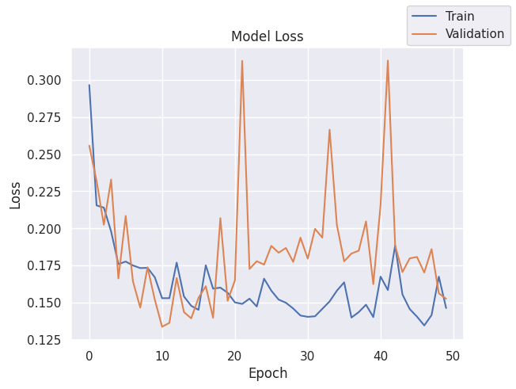

```python
plot(history,'loss')
```

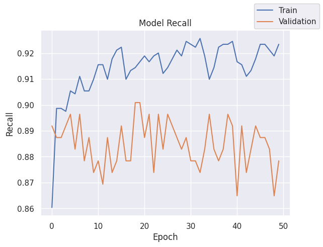

```python
plot(history,'recall')
```

```python
model2_train_perf = model_performance_classification(model2, X_train, y_train)
model2_train_perf
```

```
500/500 ━━━━━━━━━━━━━━━━━━━━ 1s 977us/step
```

|  | Accuracy | Recall | Precision | F1 Score |
| --- | --- | --- | --- | --- |
| 0 | 0.993437 | 0.993437 | 0.99336 | 0.993379 |

```python
model2_val_perf = model_performance_classification(model2, X_val, y_val)
model2_val_perf
```

```
125/125 ━━━━━━━━━━━━━━━━━━━━ 0s 1ms/step
```

|  | Accuracy | Recall | Precision | F1 Score |
| --- | --- | --- | --- | --- |
| 0 | 0.99075 | 0.99075 | 0.990573 | 0.990576 |

Observations:

- High training Recall score that almost matches Model 1
- Highest validation Recall score of the three models so far
- This model generalizes the best of the three models so far

## Model 3

- Added droput to regularize it
  - one hidden layer of 64 units to learn general patterns
  - one hidden layer of 32 units to learn general patterns
  - activation function of ReLU to learn nonlinear features efficiently
  - Sigmoid output which is useful for binary classification
  - Adam optimizer with learning rate to introduce momentum along with adaptive learning rate
  - class weight

```python
# clears the current Keras session, resetting all layers and models previously created, freeing up memory and resources.
tf.keras.backend.clear_session()
```

```python
# initializing the neural network with one hidden layer and activation function of ReLU
model3 = Sequential()
model3.add(Dense(64, activation = 'relu', input_dim = X_train.shape[1]))
model3.add(Dropout(0.4))
model3.add(Dense(32, activation= 'relu'))
model3.add(Dropout(0.2))
model3.add(Dense(1, activation='sigmoid'))
```

```python
# printing the summary
model3.summary()
```

```
Model: "sequential"
```

```
┏━━━━━━━━━━━━━━━━━━━━━━━━━━━━━━━━━┳━━━━━━━━━━━━━━━━━━━━━━━━┳━━━━━━━━━━━━━━━┓
┃ Layer (type)                    ┃ Output Shape           ┃       Param # ┃
┡━━━━━━━━━━━━━━━━━━━━━━━━━━━━━━━━━╇━━━━━━━━━━━━━━━━━━━━━━━━╇━━━━━━━━━━━━━━━┩
│ dense (Dense)                   │ (None, 64)             │         2,624 │
├─────────────────────────────────┼────────────────────────┼───────────────┤
│ dropout (Dropout)               │ (None, 64)             │             0 │
├─────────────────────────────────┼────────────────────────┼───────────────┤
│ dense_1 (Dense)                 │ (None, 32)             │         2,080 │
├─────────────────────────────────┼────────────────────────┼───────────────┤
│ dropout_1 (Dropout)             │ (None, 32)             │             0 │
├─────────────────────────────────┼────────────────────────┼───────────────┤
│ dense_2 (Dense)                 │ (None, 1)              │            33 │
└─────────────────────────────────┴────────────────────────┴───────────────┘
```

```
 Total params: 4,737 (18.50 KB)
```

```
 Trainable params: 4,737 (18.50 KB)
```

```
 Non-trainable params: 0 (0.00 B)
```

```python
# compile the model
# define the optimizer using Adam
optimizer = keras.optimizers.Adam(learning_rate=0.01)
model3.compile(
    loss='binary_crossentropy',
    optimizer=optimizer,
    metrics=[Recall()]
)
```

```python
# time.time() returns the time in seconds
start = time.time()
# Fitting the model.
history = model3.fit(X_train, y_train, validation_data=(X_val,y_val) , batch_size=batch_size, epochs=epochs, class_weight=cw_dict)
# time.time() returns the time in seconds
end=time.time()
```

```
250/250 ━━━━━━━━━━━━━━━━━━━━ 3s 5ms/step - loss: 0.6858 - recall: 0.7192 - val_loss: 0.3308 - val_recall: 0.8829
250/250 ━━━━━━━━━━━━━━━━━━━━ 1s 5ms/step - loss: 0.2836 - recall: 0.8620 - val_loss: 0.3182 - val_recall: 0.8694
250/250 ━━━━━━━━━━━━━━━━━━━━ 1s 5ms/step - loss: 0.2500 - recall: 0.8755 - val_loss: 0.2620 - val_recall: 0.8784
250/250 ━━━━━━━━━━━━━━━━━━━━ 1s 3ms/step - loss: 0.2363 - recall: 0.8620 - val_loss: 0.2397 - val_recall: 0.8874
250/250 ━━━━━━━━━━━━━━━━━━━━ 1s 3ms/step - loss: 0.2261 - recall: 0.8847 - val_loss: 0.2571 - val_recall: 0.8919
250/250 ━━━━━━━━━━━━━━━━━━━━ 1s 3ms/step - loss: 0.2323 - recall: 0.8734 - val_loss: 0.2102 - val_recall: 0.8694
250/250 ━━━━━━━━━━━━━━━━━━━━ 1s 3ms/step - loss: 0.2309 - recall: 0.8693 - val_loss: 0.1403 - val_recall: 0.8649
250/250 ━━━━━━━━━━━━━━━━━━━━ 1s 3ms/step - loss: 0.2355 - recall: 0.8753 - val_loss: 0.1811 - val_recall: 0.8604
250/250 ━━━━━━━━━━━━━━━━━━━━ 1s 3ms/step - loss: 0.2136 - recall: 0.8775 - val_loss: 0.1976 - val_recall: 0.8784
250/250 ━━━━━━━━━━━━━━━━━━━━ 1s 3ms/step - loss: 0.1998 - recall: 0.8904 - val_loss: 0.1593 - val_recall: 0.8694
250/250 ━━━━━━━━━━━━━━━━━━━━ 1s 3ms/step - loss: 0.2078 - recall: 0.8827 - val_loss: 0.1644 - val_recall: 0.8604
250/250 ━━━━━━━━━━━━━━━━━━━━ 1s 3ms/step - loss: 0.2077 - recall: 0.8859 - val_loss: 0.1709 - val_recall: 0.8829
250/250 ━━━━━━━━━━━━━━━━━━━━ 1s 3ms/step - loss: 0.2085 - recall: 0.8905 - val_loss: 0.1594 - val_recall: 0.8649
250/250 ━━━━━━━━━━━━━━━━━━━━ 2s 4ms/step - loss: 0.1921 - recall: 0.8866 - val_loss: 0.1610 - val_recall: 0.8649
250/250 ━━━━━━━━━━━━━━━━━━━━ 2s 5ms/step - loss: 0.1982 - recall: 0.8882 - val_loss: 0.1884 - val_recall: 0.8784
250/250 ━━━━━━━━━━━━━━━━━━━━ 1s 5ms/step - loss: 0.2037 - recall: 0.8909 - val_loss: 0.1565 - val_recall: 0.8694
250/250 ━━━━━━━━━━━━━━━━━━━━ 1s 3ms/step - loss: 0.1965 - recall: 0.8764 - val_loss: 0.1724 - val_recall: 0.8919
250/250 ━━━━━━━━━━━━━━━━━━━━ 1s 3ms/step - loss: 0.1910 - recall: 0.8938 - val_loss: 0.1644 - val_recall: 0.8739
250/250 ━━━━━━━━━━━━━━━━━━━━ 1s 3ms/step - loss: 0.1947 - recall: 0.8902 - val_loss: 0.1836 - val_recall: 0.8739
250/250 ━━━━━━━━━━━━━━━━━━━━ 1s 3ms/step - loss: 0.1900 - recall: 0.8985 - val_loss: 0.1770 - val_recall: 0.8604
250/250 ━━━━━━━━━━━━━━━━━━━━ 1s 3ms/step - loss: 0.2079 - recall: 0.8734 - val_loss: 0.1753 - val_recall: 0.8784
250/250 ━━━━━━━━━━━━━━━━━━━━ 1s 3ms/step - loss: 0.1894 - recall: 0.8918 - val_loss: 0.1741 - val_recall: 0.8739
250/250 ━━━━━━━━━━━━━━━━━━━━ 1s 3ms/step - loss: 0.1887 - recall: 0.8952 - val_loss: 0.1544 - val_recall: 0.8694
250/250 ━━━━━━━━━━━━━━━━━━━━ 1s 3ms/step - loss: 0.1827 - recall: 0.8929 - val_loss: 0.1589 - val_recall: 0.8784
250/250 ━━━━━━━━━━━━━━━━━━━━ 1s 2ms/step - loss: 0.2025 - recall: 0.8890 - val_loss: 0.1998 - val_recall: 0.8829
250/250 ━━━━━━━━━━━━━━━━━━━━ 2s 4ms/step - loss: 0.1843 - recall: 0.8962 - val_loss: 0.1740 - val_recall: 0.8784
250/250 ━━━━━━━━━━━━━━━━━━━━ 1s 5ms/step - loss: 0.2050 - recall: 0.8882 - val_loss: 0.2015 - val_recall: 0.8649
250/250 ━━━━━━━━━━━━━━━━━━━━ 1s 4ms/step - loss: 0.2037 - recall: 0.8819 - val_loss: 0.1735 - val_recall: 0.8784
250/250 ━━━━━━━━━━━━━━━━━━━━ 1s 3ms/step - loss: 0.2015 - recall: 0.8804 - val_loss: 0.2120 - val_recall: 0.8739
250/250 ━━━━━━━━━━━━━━━━━━━━ 1s 3ms/step - loss: 0.2016 - recall: 0.8851 - val_loss: 0.1934 - val_recall: 0.8739
250/250 ━━━━━━━━━━━━━━━━━━━━ 1s 2ms/step - loss: 0.2105 - recall: 0.8846 - val_loss: 0.1788 - val_recall: 0.8739
250/250 ━━━━━━━━━━━━━━━━━━━━ 1s 3ms/step - loss: 0.2183 - recall: 0.8793 - val_loss: 0.1879 - val_recall: 0.8739
250/250 ━━━━━━━━━━━━━━━━━━━━ 1s 3ms/step - loss: 0.1948 - recall: 0.8892 - val_loss: 0.1775 - val_recall: 0.8829
250/250 ━━━━━━━━━━━━━━━━━━━━ 1s 3ms/step - loss: 0.1770 - recall: 0.8986 - val_loss: 0.1718 - val_recall: 0.8559
250/250 ━━━━━━━━━━━━━━━━━━━━ 1s 3ms/step - loss: 0.1860 - recall: 0.8915 - val_loss: 0.1793 - val_recall: 0.8694
250/250 ━━━━━━━━━━━━━━━━━━━━ 1s 3ms/step - loss: 0.1924 - recall: 0.8861 - val_loss: 0.1961 - val_recall: 0.8829
250/250 ━━━━━━━━━━━━━━━━━━━━ 2s 5ms/step - loss: 0.1829 - recall: 0.8986 - val_loss: 0.1725 - val_recall: 0.8739
250/250 ━━━━━━━━━━━━━━━━━━━━ 1s 5ms/step - loss: 0.1919 - recall: 0.8894 - val_loss: 0.1758 - val_recall: 0.8874
250/250 ━━━━━━━━━━━━━━━━━━━━ 1s 5ms/step - loss: 0.1752 - recall: 0.9030 - val_loss: 0.1822 - val_recall: 0.8649
250/250 ━━━━━━━━━━━━━━━━━━━━ 1s 3ms/step - loss: 0.1834 - recall: 0.8976 - val_loss: 0.1841 - val_recall: 0.8739
250/250 ━━━━━━━━━━━━━━━━━━━━ 1s 3ms/step - loss: 0.1815 - recall: 0.9032 - val_loss: 0.1625 - val_recall: 0.8649
250/250 ━━━━━━━━━━━━━━━━━━━━ 1s 3ms/step - loss: 0.1945 - recall: 0.8875 - val_loss: 0.1954 - val_recall: 0.8739
250/250 ━━━━━━━━━━━━━━━━━━━━ 1s 3ms/step - loss: 0.1797 - recall: 0.9001 - val_loss: 0.1851 - val_recall: 0.8784
250/250 ━━━━━━━━━━━━━━━━━━━━ 1s 2ms/step - loss: 0.1813 - recall: 0.8904 - val_loss: 0.1807 - val_recall: 0.8739
250/250 ━━━━━━━━━━━━━━━━━━━━ 1s 3ms/step - loss: 0.1766 - recall: 0.8999 - val_loss: 0.2104 - val_recall: 0.8694
250/250 ━━━━━━━━━━━━━━━━━━━━ 1s 3ms/step - loss: 0.1894 - recall: 0.8917 - val_loss: 0.2380 - val_recall: 0.8694
250/250 ━━━━━━━━━━━━━━━━━━━━ 1s 3ms/step - loss: 0.2107 - recall: 0.8805 - val_loss: 0.2610 - val_recall: 0.8739
250/250 ━━━━━━━━━━━━━━━━━━━━ 1s 3ms/step - loss: 0.1999 - recall: 0.8889 - val_loss: 0.2550 - val_recall: 0.8784
250/250 ━━━━━━━━━━━━━━━━━━━━ 1s 2ms/step - loss: 0.2427 - recall: 0.8877 - val_loss: 0.2227 - val_recall: 0.8694
250/250 ━━━━━━━━━━━━━━━━━━━━ 1s 3ms/step - loss: 0.1967 - recall: 0.8862 - val_loss: 0.2067 - val_recall: 0.8694
```

```python
print("Time taken in seconds ",end-start)
```

```
Time taken in seconds  55.876065731048584
```

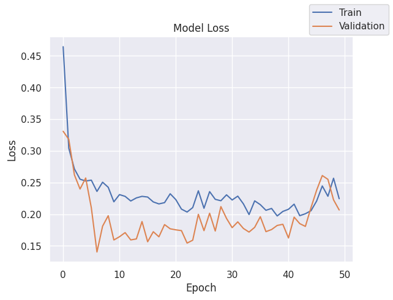

```python
plot(history,'loss')
```

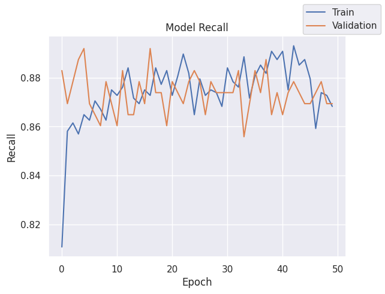

```python
plot(history,'recall')
```

```python
model3_train_perf = model_performance_classification(model3, X_train, y_train)
model3_train_perf
```

```
500/500 ━━━━━━━━━━━━━━━━━━━━ 1s 980us/step
```

|  | Accuracy | Recall | Precision | F1 Score |
| --- | --- | --- | --- | --- |
| 0 | 0.99225 | 0.99225 | 0.992129 | 0.99214 |

```python
model3_val_perf = model_performance_classification(model3, X_val, y_val)
model3_val_perf
```

```
125/125 ━━━━━━━━━━━━━━━━━━━━ 0s 1ms/step
```

|  | Accuracy | Recall | Precision | F1 Score |
| --- | --- | --- | --- | --- |
| 0 | 0.99 | 0.99 | 0.989792 | 0.989801 |

Observations:

## Model 4

```python
# clears the current Keras session, resetting all layers and models previously created, freeing up memory and resources.
tf.keras.backend.clear_session()
```

```python
# initializing the neural network with one hidden layer and activation function of ReLU
model4 = Sequential()
model4.add(Dense(64, activation = 'relu', input_dim = X_train.shape[1]))
model4.add(BatchNormalization())
model4.add(Dense(32, activation= 'relu'))
model4.add(BatchNormalization())
model4.add(Dense(1, activation='sigmoid'))
```

```python
# printing the summary
model4.summary()
```

```
Model: "sequential"
```

```
┏━━━━━━━━━━━━━━━━━━━━━━━━━━━━━━━━━┳━━━━━━━━━━━━━━━━━━━━━━━━┳━━━━━━━━━━━━━━━┓
┃ Layer (type)                    ┃ Output Shape           ┃       Param # ┃
┡━━━━━━━━━━━━━━━━━━━━━━━━━━━━━━━━━╇━━━━━━━━━━━━━━━━━━━━━━━━╇━━━━━━━━━━━━━━━┩
│ dense (Dense)                   │ (None, 64)             │         2,624 │
├─────────────────────────────────┼────────────────────────┼───────────────┤
│ batch_normalization             │ (None, 64)             │           256 │
│ (BatchNormalization)            │                        │               │
├─────────────────────────────────┼────────────────────────┼───────────────┤
│ dense_1 (Dense)                 │ (None, 32)             │         2,080 │
├─────────────────────────────────┼────────────────────────┼───────────────┤
│ batch_normalization_1           │ (None, 32)             │           128 │
│ (BatchNormalization)            │                        │               │
├─────────────────────────────────┼────────────────────────┼───────────────┤
│ dense_2 (Dense)                 │ (None, 1)              │            33 │
└─────────────────────────────────┴────────────────────────┴───────────────┘
```

```
 Total params: 5,121 (20.00 KB)
```

```
 Trainable params: 4,929 (19.25 KB)
```

```
 Non-trainable params: 192 (768.00 B)
```

```python
# compile the model
# define the optimizer using Adam
optimizer = keras.optimizers.Adam(learning_rate=0.01)
model4.compile(
    loss='binary_crossentropy',
    optimizer=optimizer,
    metrics=[Recall()]
)
```

```python
# time.time() returns the time in seconds
start = time.time()
# Fitting the model.
history = model4.fit(X_train, y_train, validation_data=(X_val,y_val) , batch_size=batch_size, epochs=epochs, class_weight=cw_dict)
# time.time() returns the time in seconds
end=time.time()
```

```
250/250 ━━━━━━━━━━━━━━━━━━━━ 4s 5ms/step - loss: 0.3488 - recall: 0.8595 - val_loss: 0.1964 - val_recall: 0.8829
250/250 ━━━━━━━━━━━━━━━━━━━━ 1s 3ms/step - loss: 0.2030 - recall: 0.9105 - val_loss: 0.1410 - val_recall: 0.8739
250/250 ━━━━━━━━━━━━━━━━━━━━ 1s 3ms/step - loss: 0.1734 - recall: 0.9241 - val_loss: 0.1937 - val_recall: 0.8919
250/250 ━━━━━━━━━━━━━━━━━━━━ 1s 3ms/step - loss: 0.1644 - recall: 0.9265 - val_loss: 0.1594 - val_recall: 0.8919
250/250 ━━━━━━━━━━━━━━━━━━━━ 1s 3ms/step - loss: 0.1575 - recall: 0.9228 - val_loss: 0.1339 - val_recall: 0.8739
250/250 ━━━━━━━━━━━━━━━━━━━━ 1s 3ms/step - loss: 0.1457 - recall: 0.9245 - val_loss: 0.1045 - val_recall: 0.8739
250/250 ━━━━━━━━━━━━━━━━━━━━ 1s 3ms/step - loss: 0.1367 - recall: 0.9333 - val_loss: 0.1241 - val_recall: 0.8739
250/250 ━━━━━━━━━━━━━━━━━━━━ 1s 3ms/step - loss: 0.1327 - recall: 0.9308 - val_loss: 0.1468 - val_recall: 0.8829
250/250 ━━━━━━━━━━━━━━━━━━━━ 1s 3ms/step - loss: 0.1301 - recall: 0.9350 - val_loss: 0.1152 - val_recall: 0.8874
250/250 ━━━━━━━━━━━━━━━━━━━━ 1s 4ms/step - loss: 0.1268 - recall: 0.9317 - val_loss: 0.1127 - val_recall: 0.8694
250/250 ━━━━━━━━━━━━━━━━━━━━ 1s 5ms/step - loss: 0.1155 - recall: 0.9355 - val_loss: 0.1400 - val_recall: 0.8784
250/250 ━━━━━━━━━━━━━━━━━━━━ 1s 5ms/step - loss: 0.1201 - recall: 0.9360 - val_loss: 0.1182 - val_recall: 0.8739
250/250 ━━━━━━━━━━━━━━━━━━━━ 1s 3ms/step - loss: 0.1175 - recall: 0.9331 - val_loss: 0.1573 - val_recall: 0.8829
250/250 ━━━━━━━━━━━━━━━━━━━━ 1s 3ms/step - loss: 0.1110 - recall: 0.9400 - val_loss: 0.1030 - val_recall: 0.8739
250/250 ━━━━━━━━━━━━━━━━━━━━ 1s 3ms/step - loss: 0.1075 - recall: 0.9380 - val_loss: 0.1381 - val_recall: 0.8874
250/250 ━━━━━━━━━━━━━━━━━━━━ 1s 3ms/step - loss: 0.1100 - recall: 0.9369 - val_loss: 0.1334 - val_recall: 0.8784
250/250 ━━━━━━━━━━━━━━━━━━━━ 1s 3ms/step - loss: 0.1070 - recall: 0.9401 - val_loss: 0.1208 - val_recall: 0.8829
250/250 ━━━━━━━━━━━━━━━━━━━━ 1s 3ms/step - loss: 0.0980 - recall: 0.9367 - val_loss: 0.1253 - val_recall: 0.8874
250/250 ━━━━━━━━━━━━━━━━━━━━ 1s 3ms/step - loss: 0.0956 - recall: 0.9489 - val_loss: 0.1098 - val_recall: 0.8874
250/250 ━━━━━━━━━━━━━━━━━━━━ 1s 3ms/step - loss: 0.0837 - recall: 0.9497 - val_loss: 0.1676 - val_recall: 0.9054
250/250 ━━━━━━━━━━━━━━━━━━━━ 1s 3ms/step - loss: 0.0888 - recall: 0.9541 - val_loss: 0.1386 - val_recall: 0.8874
250/250 ━━━━━━━━━━━━━━━━━━━━ 1s 3ms/step - loss: 0.0946 - recall: 0.9416 - val_loss: 0.1357 - val_recall: 0.8829
250/250 ━━━━━━━━━━━━━━━━━━━━ 1s 3ms/step - loss: 0.0798 - recall: 0.9576 - val_loss: 0.1270 - val_recall: 0.8919
250/250 ━━━━━━━━━━━━━━━━━━━━ 1s 5ms/step - loss: 0.0867 - recall: 0.9434 - val_loss: 0.1323 - val_recall: 0.8829
250/250 ━━━━━━━━━━━━━━━━━━━━ 1s 5ms/step - loss: 0.0730 - recall: 0.9578 - val_loss: 0.1120 - val_recall: 0.8874
250/250 ━━━━━━━━━━━━━━━━━━━━ 2s 3ms/step - loss: 0.0648 - recall: 0.9620 - val_loss: 0.1487 - val_recall: 0.9009
250/250 ━━━━━━━━━━━━━━━━━━━━ 1s 3ms/step - loss: 0.0752 - recall: 0.9496 - val_loss: 0.1270 - val_recall: 0.8829
250/250 ━━━━━━━━━━━━━━━━━━━━ 1s 3ms/step - loss: 0.0815 - recall: 0.9493 - val_loss: 0.1746 - val_recall: 0.8874
250/250 ━━━━━━━━━━━━━━━━━━━━ 1s 3ms/step - loss: 0.0746 - recall: 0.9584 - val_loss: 0.1267 - val_recall: 0.8829
250/250 ━━━━━━━━━━━━━━━━━━━━ 1s 3ms/step - loss: 0.0657 - recall: 0.9586 - val_loss: 0.1015 - val_recall: 0.8739
250/250 ━━━━━━━━━━━━━━━━━━━━ 1s 3ms/step - loss: 0.0589 - recall: 0.9662 - val_loss: 0.1130 - val_recall: 0.8784
250/250 ━━━━━━━━━━━━━━━━━━━━ 1s 3ms/step - loss: 0.0720 - recall: 0.9555 - val_loss: 0.1280 - val_recall: 0.8829
250/250 ━━━━━━━━━━━━━━━━━━━━ 1s 3ms/step - loss: 0.0653 - recall: 0.9670 - val_loss: 0.1175 - val_recall: 0.8874
250/250 ━━━━━━━━━━━━━━━━━━━━ 2s 4ms/step - loss: 0.0583 - recall: 0.9694 - val_loss: 0.0982 - val_recall: 0.8694
250/250 ━━━━━━━━━━━━━━━━━━━━ 1s 5ms/step - loss: 0.0687 - recall: 0.9535 - val_loss: 0.2356 - val_recall: 0.9099
250/250 ━━━━━━━━━━━━━━━━━━━━ 1s 5ms/step - loss: 0.0682 - recall: 0.9614 - val_loss: 0.0959 - val_recall: 0.8874
250/250 ━━━━━━━━━━━━━━━━━━━━ 1s 3ms/step - loss: 0.0464 - recall: 0.9717 - val_loss: 0.0928 - val_recall: 0.8784
250/250 ━━━━━━━━━━━━━━━━━━━━ 1s 3ms/step - loss: 0.0579 - recall: 0.9707 - val_loss: 0.2457 - val_recall: 0.9009
250/250 ━━━━━━━━━━━━━━━━━━━━ 1s 3ms/step - loss: 0.0721 - recall: 0.9619 - val_loss: 0.1132 - val_recall: 0.8829
250/250 ━━━━━━━━━━━━━━━━━━━━ 1s 3ms/step - loss: 0.0405 - recall: 0.9791 - val_loss: 0.0977 - val_recall: 0.8784
250/250 ━━━━━━━━━━━━━━━━━━━━ 1s 3ms/step - loss: 0.0313 - recall: 0.9845 - val_loss: 0.1174 - val_recall: 0.8829
250/250 ━━━━━━━━━━━━━━━━━━━━ 1s 3ms/step - loss: 0.0415 - recall: 0.9765 - val_loss: 0.1619 - val_recall: 0.8919
250/250 ━━━━━━━━━━━━━━━━━━━━ 1s 3ms/step - loss: 0.0442 - recall: 0.9808 - val_loss: 0.1965 - val_recall: 0.8784
250/250 ━━━━━━━━━━━━━━━━━━━━ 1s 3ms/step - loss: 0.0438 - recall: 0.9831 - val_loss: 0.1215 - val_recall: 0.8829
250/250 ━━━━━━━━━━━━━━━━━━━━ 1s 3ms/step - loss: 0.0328 - recall: 0.9829 - val_loss: 0.1125 - val_recall: 0.8784
250/250 ━━━━━━━━━━━━━━━━━━━━ 1s 3ms/step - loss: 0.0495 - recall: 0.9749 - val_loss: 0.1859 - val_recall: 0.8964
250/250 ━━━━━━━━━━━━━━━━━━━━ 1s 3ms/step - loss: 0.0783 - recall: 0.9640 - val_loss: 0.1243 - val_recall: 0.8739
250/250 ━━━━━━━━━━━━━━━━━━━━ 2s 4ms/step - loss: 0.0537 - recall: 0.9705 - val_loss: 0.1425 - val_recall: 0.8739
250/250 ━━━━━━━━━━━━━━━━━━━━ 1s 4ms/step - loss: 0.0500 - recall: 0.9691 - val_loss: 0.0943 - val_recall: 0.8829
250/250 ━━━━━━━━━━━━━━━━━━━━ 1s 5ms/step - loss: 0.0476 - recall: 0.9720 - val_loss: 0.0992 - val_recall: 0.8829
```

```python
print("Time taken in seconds ",end-start)
```

```
Time taken in seconds  57.52776074409485
```

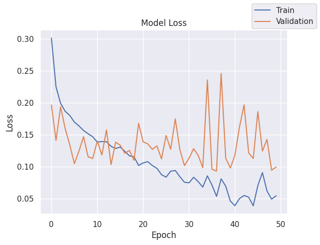

```python
plot(history,'loss')
```

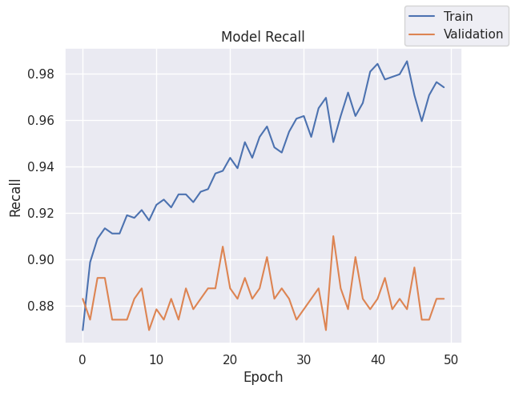

```python
plot(history,'recall')
```

```python
model4_train_perf = model_performance_classification(model4, X_train, y_train)
model4_train_perf
```

```
500/500 ━━━━━━━━━━━━━━━━━━━━ 1s 1ms/step
```

|  | Accuracy | Recall | Precision | F1 Score |
| --- | --- | --- | --- | --- |
| 0 | 0.985563 | 0.985563 | 0.987073 | 0.986047 |

```python
model4_val_perf = model_performance_classification(model4, X_val, y_val)
model4_val_perf
```

```
125/125 ━━━━━━━━━━━━━━━━━━━━ 0s 1ms/step
```

|  | Accuracy | Recall | Precision | F1 Score |
| --- | --- | --- | --- | --- |
| 0 | 0.9785 | 0.9785 | 0.980433 | 0.979216 |

Observations:

- Recall scores for training and validation are the weakest of all models run so far
- This model suggests underperforming and maybe some of the hyperparameters are weak

## Model 5

- Added another hidden layer of 128 units to enhance learning of complex patterns
  - one hidden layer of 64 units to learn general patterns
  - one hidden layer of 32 units to learn general patterns
  - activation function of ReLU to learn nonlinear features efficiently
  - Sigmoid output which is useful for binary classification
  - Adam optimizer with learning rate to introduce momentum along with adaptive learning rate
  - class weight

```python
# clears the current Keras session, resetting all layers and models previously created, freeing up memory and resources.
tf.keras.backend.clear_session()
```

```python
# initializing the neural network with one hidden layer and activation function of ReLU
model5 = Sequential()
model5.add(Dense(128, activation = 'relu', input_dim = X_train.shape[1]))
model5.add(Dense(64, activation= 'relu'))
model5.add(Dense(32, activation= 'relu'))
model5.add(Dense(1, activation='sigmoid'))
```

```python
# printing the summary
model5.summary()
```

```
Model: "sequential"
```

```
┏━━━━━━━━━━━━━━━━━━━━━━━━━━━━━━━━━┳━━━━━━━━━━━━━━━━━━━━━━━━┳━━━━━━━━━━━━━━━┓
┃ Layer (type)                    ┃ Output Shape           ┃       Param # ┃
┡━━━━━━━━━━━━━━━━━━━━━━━━━━━━━━━━━╇━━━━━━━━━━━━━━━━━━━━━━━━╇━━━━━━━━━━━━━━━┩
│ dense (Dense)                   │ (None, 128)            │         5,248 │
├─────────────────────────────────┼────────────────────────┼───────────────┤
│ dense_1 (Dense)                 │ (None, 64)             │         8,256 │
├─────────────────────────────────┼────────────────────────┼───────────────┤
│ dense_2 (Dense)                 │ (None, 32)             │         2,080 │
├─────────────────────────────────┼────────────────────────┼───────────────┤
│ dense_3 (Dense)                 │ (None, 1)              │            33 │
└─────────────────────────────────┴────────────────────────┴───────────────┘
```

```
 Total params: 15,617 (61.00 KB)
```

```
 Trainable params: 15,617 (61.00 KB)
```

```
 Non-trainable params: 0 (0.00 B)
```

```python
# compile the model
# define the optimizer using Adam
optimizer = keras.optimizers.Adam(learning_rate=0.01)
model5.compile(
    loss='binary_crossentropy',
    optimizer=optimizer,
    metrics=[Recall()]
)
```

```python
# time.time() returns the time in seconds
start = time.time()
# Fitting the model.
history = model5.fit(X_train, y_train, validation_data=(X_val,y_val) , batch_size=batch_size, epochs=epochs, class_weight=cw_dict)
# time.time() returns the time in seconds
end=time.time()
```

```
250/250 ━━━━━━━━━━━━━━━━━━━━ 3s 6ms/step - loss: 0.4341 - recall: 0.7912 - val_loss: 0.3077 - val_recall: 0.8874
250/250 ━━━━━━━━━━━━━━━━━━━━ 2s 3ms/step - loss: 0.2079 - recall: 0.9017 - val_loss: 0.2772 - val_recall: 0.9009
250/250 ━━━━━━━━━━━━━━━━━━━━ 1s 3ms/step - loss: 0.1959 - recall: 0.9102 - val_loss: 0.2363 - val_recall: 0.8964
250/250 ━━━━━━━━━━━━━━━━━━━━ 1s 2ms/step - loss: 0.1674 - recall: 0.9157 - val_loss: 0.2068 - val_recall: 0.8829
250/250 ━━━━━━━━━━━━━━━━━━━━ 1s 3ms/step - loss: 0.1578 - recall: 0.9211 - val_loss: 0.1792 - val_recall: 0.8964
250/250 ━━━━━━━━━━━━━━━━━━━━ 1s 2ms/step - loss: 0.1489 - recall: 0.9236 - val_loss: 0.4593 - val_recall: 0.8829
250/250 ━━━━━━━━━━━━━━━━━━━━ 1s 2ms/step - loss: 0.1621 - recall: 0.9154 - val_loss: 0.2105 - val_recall: 0.8784
250/250 ━━━━━━━━━━━━━━━━━━━━ 1s 2ms/step - loss: 0.1633 - recall: 0.9195 - val_loss: 0.1649 - val_recall: 0.8874
250/250 ━━━━━━━━━━━━━━━━━━━━ 1s 3ms/step - loss: 0.1442 - recall: 0.9223 - val_loss: 0.1506 - val_recall: 0.8919
250/250 ━━━━━━━━━━━━━━━━━━━━ 1s 3ms/step - loss: 0.1371 - recall: 0.9262 - val_loss: 0.1538 - val_recall: 0.8964
250/250 ━━━━━━━━━━━━━━━━━━━━ 2s 4ms/step - loss: 0.1301 - recall: 0.9306 - val_loss: 0.1548 - val_recall: 0.8829
250/250 ━━━━━━━━━━━━━━━━━━━━ 1s 4ms/step - loss: 0.1585 - recall: 0.9228 - val_loss: 0.2586 - val_recall: 0.8829
250/250 ━━━━━━━━━━━━━━━━━━━━ 1s 5ms/step - loss: 0.3026 - recall: 0.8990 - val_loss: 0.1756 - val_recall: 0.8919
250/250 ━━━━━━━━━━━━━━━━━━━━ 1s 3ms/step - loss: 0.1420 - recall: 0.9232 - val_loss: 0.1461 - val_recall: 0.8874
250/250 ━━━━━━━━━━━━━━━━━━━━ 1s 2ms/step - loss: 0.1324 - recall: 0.9267 - val_loss: 0.1415 - val_recall: 0.8874
250/250 ━━━━━━━━━━━━━━━━━━━━ 1s 3ms/step - loss: 0.1281 - recall: 0.9327 - val_loss: 0.1395 - val_recall: 0.8874
250/250 ━━━━━━━━━━━━━━━━━━━━ 1s 3ms/step - loss: 0.1277 - recall: 0.9297 - val_loss: 0.1328 - val_recall: 0.8874
250/250 ━━━━━━━━━━━━━━━━━━━━ 1s 3ms/step - loss: 0.1244 - recall: 0.9327 - val_loss: 0.1442 - val_recall: 0.8874
250/250 ━━━━━━━━━━━━━━━━━━━━ 1s 3ms/step - loss: 0.1237 - recall: 0.9327 - val_loss: 0.1573 - val_recall: 0.8829
250/250 ━━━━━━━━━━━━━━━━━━━━ 1s 3ms/step - loss: 0.1308 - recall: 0.9313 - val_loss: 0.1475 - val_recall: 0.8964
250/250 ━━━━━━━━━━━━━━━━━━━━ 1s 3ms/step - loss: 0.1318 - recall: 0.9298 - val_loss: 0.1483 - val_recall: 0.8874
250/250 ━━━━━━━━━━━━━━━━━━━━ 1s 3ms/step - loss: 0.1303 - recall: 0.9305 - val_loss: 0.1712 - val_recall: 0.8874
250/250 ━━━━━━━━━━━━━━━━━━━━ 1s 3ms/step - loss: 0.1276 - recall: 0.9331 - val_loss: 0.1525 - val_recall: 0.8964
250/250 ━━━━━━━━━━━━━━━━━━━━ 1s 3ms/step - loss: 0.1266 - recall: 0.9324 - val_loss: 0.1557 - val_recall: 0.8874
250/250 ━━━━━━━━━━━━━━━━━━━━ 2s 5ms/step - loss: 0.1268 - recall: 0.9297 - val_loss: 0.1573 - val_recall: 0.8919
250/250 ━━━━━━━━━━━━━━━━━━━━ 1s 4ms/step - loss: 0.1281 - recall: 0.9313 - val_loss: 0.1961 - val_recall: 0.8829
250/250 ━━━━━━━━━━━━━━━━━━━━ 1s 4ms/step - loss: 0.1549 - recall: 0.9206 - val_loss: 0.1557 - val_recall: 0.8874
250/250 ━━━━━━━━━━━━━━━━━━━━ 1s 2ms/step - loss: 0.1304 - recall: 0.9290 - val_loss: 0.1423 - val_recall: 0.8919
250/250 ━━━━━━━━━━━━━━━━━━━━ 1s 3ms/step - loss: 0.1231 - recall: 0.9338 - val_loss: 0.1771 - val_recall: 0.8919
250/250 ━━━━━━━━━━━━━━━━━━━━ 1s 2ms/step - loss: 0.1271 - recall: 0.9323 - val_loss: 0.2099 - val_recall: 0.8964
250/250 ━━━━━━━━━━━━━━━━━━━━ 1s 3ms/step - loss: 0.1268 - recall: 0.9337 - val_loss: 0.1701 - val_recall: 0.8919
250/250 ━━━━━━━━━━━━━━━━━━━━ 1s 3ms/step - loss: 0.1230 - recall: 0.9333 - val_loss: 0.2502 - val_recall: 0.9054
250/250 ━━━━━━━━━━━━━━━━━━━━ 1s 2ms/step - loss: 0.1350 - recall: 0.9310 - val_loss: 0.2137 - val_recall: 0.8919
250/250 ━━━━━━━━━━━━━━━━━━━━ 1s 3ms/step - loss: 0.1295 - recall: 0.9332 - val_loss: 0.1882 - val_recall: 0.8964
250/250 ━━━━━━━━━━━━━━━━━━━━ 1s 3ms/step - loss: 0.1271 - recall: 0.9336 - val_loss: 0.2024 - val_recall: 0.8874
250/250 ━━━━━━━━━━━━━━━━━━━━ 1s 3ms/step - loss: 0.1237 - recall: 0.9323 - val_loss: 0.2708 - val_recall: 0.9054
250/250 ━━━━━━━━━━━━━━━━━━━━ 1s 3ms/step - loss: 0.1726 - recall: 0.9135 - val_loss: 0.3021 - val_recall: 0.8559
250/250 ━━━━━━━━━━━━━━━━━━━━ 2s 5ms/step - loss: 0.2663 - recall: 0.8413 - val_loss: 0.5238 - val_recall: 0.7838
250/250 ━━━━━━━━━━━━━━━━━━━━ 1s 5ms/step - loss: 0.2730 - recall: 0.8536 - val_loss: 0.3527 - val_recall: 0.8649
250/250 ━━━━━━━━━━━━━━━━━━━━ 1s 4ms/step - loss: 0.1648 - recall: 0.9117 - val_loss: 0.2898 - val_recall: 0.8604
250/250 ━━━━━━━━━━━━━━━━━━━━ 1s 3ms/step - loss: 0.1525 - recall: 0.9163 - val_loss: 0.2527 - val_recall: 0.8649
250/250 ━━━━━━━━━━━━━━━━━━━━ 1s 3ms/step - loss: 0.1412 - recall: 0.9235 - val_loss: 0.2558 - val_recall: 0.8829
250/250 ━━━━━━━━━━━━━━━━━━━━ 1s 3ms/step - loss: 0.1336 - recall: 0.9295 - val_loss: 0.2034 - val_recall: 0.8829
250/250 ━━━━━━━━━━━━━━━━━━━━ 1s 3ms/step - loss: 0.1288 - recall: 0.9302 - val_loss: 0.2036 - val_recall: 0.8829
250/250 ━━━━━━━━━━━━━━━━━━━━ 1s 3ms/step - loss: 0.1274 - recall: 0.9302 - val_loss: 0.2042 - val_recall: 0.8874
250/250 ━━━━━━━━━━━━━━━━━━━━ 1s 3ms/step - loss: 0.1265 - recall: 0.9302 - val_loss: 0.2055 - val_recall: 0.8874
250/250 ━━━━━━━━━━━━━━━━━━━━ 1s 3ms/step - loss: 0.1261 - recall: 0.9302 - val_loss: 0.2082 - val_recall: 0.8829
250/250 ━━━━━━━━━━━━━━━━━━━━ 1s 3ms/step - loss: 0.1257 - recall: 0.9302 - val_loss: 0.2124 - val_recall: 0.8784
250/250 ━━━━━━━━━━━━━━━━━━━━ 2s 4ms/step - loss: 0.1253 - recall: 0.9302 - val_loss: 0.2158 - val_recall: 0.8784
250/250 ━━━━━━━━━━━━━━━━━━━━ 1s 4ms/step - loss: 0.1247 - recall: 0.9302 - val_loss: 0.2150 - val_recall: 0.8784
```

```python
print("Time taken in seconds ",end-start)
```

```
Time taken in seconds  56.174439907073975
```

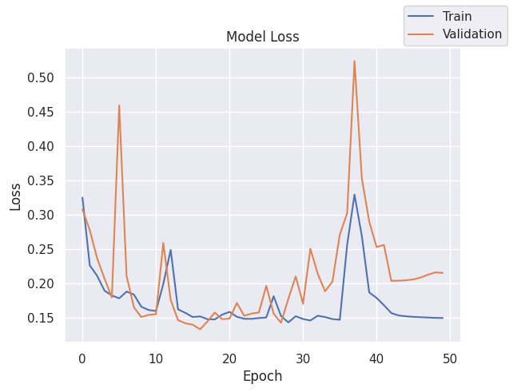

```python
plot(history,'loss')
```

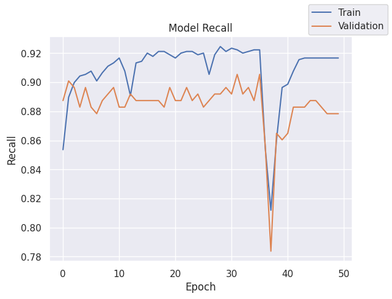

```python
plot(history,'recall')
```

```python
model5_train_perf = model_performance_classification(model5, X_train, y_train)
model5_train_perf
```

```
500/500 ━━━━━━━━━━━━━━━━━━━━ 1s 1ms/step
```

|  | Accuracy | Recall | Precision | F1 Score |
| --- | --- | --- | --- | --- |
| 0 | 0.99475 | 0.99475 | 0.994721 | 0.994657 |

```python
model5_val_perf = model_performance_classification(model5, X_val, y_val)
model5_val_perf
```

```
125/125 ━━━━━━━━━━━━━━━━━━━━ 0s 1ms/step
```

|  | Accuracy | Recall | Precision | F1 Score |
| --- | --- | --- | --- | --- |
| 0 | 0.9905 | 0.9905 | 0.990315 | 0.990332 |

Observations:

- This model has the best training performance for Recall for all models
- The validation performance for Recall is close but less than Model 2
- This results in a larger gap between training and validation than Model 2

## Model 6

- Added He normal to initialize weights for layers with ReLu activation
  - one hidden layer of 128 units to enhance learning of complex patterns
  - one hidden layer of 64 units to learn general patterns
  - one hidden layer of 32 units to learn general patterns
  - activation function of ReLU to learn nonlinear features efficiently
  - Sigmoid output which is useful for binary classification
  - Batch normalization layer to help stabilize the training process
  - Dropout layer added to help prevent overfitting
  - Adam optimizer with learning rate to introduce momentum along with adaptive learning rate
  - class weight

```python
# clears the current Keras session, resetting all layers and models previously created, freeing up memory and resources.
tf.keras.backend.clear_session()
```

```python
# initializing the neural network with one hidden layer and activation function of ReLU
model6 = Sequential()
model6.add(Dense(128, activation = 'relu', kernel_initializer='he_normal', input_dim = X_train.shape[1]))
model6.add(BatchNormalization())
model6.add(Dropout(0.4))
model6.add(BatchNormalization())
model6.add(Dense(64, activation= 'relu', kernel_initializer='he_normal'))
model6.add(Dropout(0.3))
model6.add(Dense(32, activation= 'relu', kernel_initializer='he_normal'))
model6.add(BatchNormalization())
model6.add(Dense(1, activation='sigmoid', kernel_initializer='he_normal'))
```

```python
# printing the summary
model6.summary()
```

```
Model: "sequential"
```

```
┏━━━━━━━━━━━━━━━━━━━━━━━━━━━━━━━━━┳━━━━━━━━━━━━━━━━━━━━━━━━┳━━━━━━━━━━━━━━━┓
┃ Layer (type)                    ┃ Output Shape           ┃       Param # ┃
┡━━━━━━━━━━━━━━━━━━━━━━━━━━━━━━━━━╇━━━━━━━━━━━━━━━━━━━━━━━━╇━━━━━━━━━━━━━━━┩
│ dense (Dense)                   │ (None, 128)            │         5,248 │
├─────────────────────────────────┼────────────────────────┼───────────────┤
│ batch_normalization             │ (None, 128)            │           512 │
│ (BatchNormalization)            │                        │               │
├─────────────────────────────────┼────────────────────────┼───────────────┤
│ dropout (Dropout)               │ (None, 128)            │             0 │
├─────────────────────────────────┼────────────────────────┼───────────────┤
│ batch_normalization_1           │ (None, 128)            │           512 │
│ (BatchNormalization)            │                        │               │
├─────────────────────────────────┼────────────────────────┼───────────────┤
│ dense_1 (Dense)                 │ (None, 64)             │         8,256 │
├─────────────────────────────────┼────────────────────────┼───────────────┤
│ dropout_1 (Dropout)             │ (None, 64)             │             0 │
├─────────────────────────────────┼────────────────────────┼───────────────┤
│ dense_2 (Dense)                 │ (None, 32)             │         2,080 │
├─────────────────────────────────┼────────────────────────┼───────────────┤
│ batch_normalization_2           │ (None, 32)             │           128 │
│ (BatchNormalization)            │                        │               │
├─────────────────────────────────┼────────────────────────┼───────────────┤
│ dense_3 (Dense)                 │ (None, 1)              │            33 │
└─────────────────────────────────┴────────────────────────┴───────────────┘
```

```
 Total params: 16,769 (65.50 KB)
```

```
 Trainable params: 16,193 (63.25 KB)
```

```
 Non-trainable params: 576 (2.25 KB)
```

```python
# compile the model
# define the optimizer using Adam
optimizer = keras.optimizers.Adam(learning_rate=0.001)
model6.compile(
    loss='binary_crossentropy',
    optimizer=optimizer,
    metrics=[Recall()]
)
```

```python
# time.time() returns the time in seconds
start = time.time()
# Fitting the model.
history = model6.fit(X_train, y_train, validation_data=(X_val,y_val) , batch_size=batch_size, epochs=epochs,class_weight=cw_dict)
# time.time() returns the time in seconds
end=time.time()
```

```
250/250 ━━━━━━━━━━━━━━━━━━━━ 5s 6ms/step - loss: 0.5079 - recall: 0.8184 - val_loss: 0.2421 - val_recall: 0.8739
250/250 ━━━━━━━━━━━━━━━━━━━━ 1s 3ms/step - loss: 0.3083 - recall: 0.8652 - val_loss: 0.1678 - val_recall: 0.8649
250/250 ━━━━━━━━━━━━━━━━━━━━ 1s 3ms/step - loss: 0.2537 - recall: 0.8851 - val_loss: 0.1262 - val_recall: 0.8694
250/250 ━━━━━━━━━━━━━━━━━━━━ 1s 3ms/step - loss: 0.2341 - recall: 0.8889 - val_loss: 0.1189 - val_recall: 0.8694
250/250 ━━━━━━━━━━━━━━━━━━━━ 1s 3ms/step - loss: 0.2127 - recall: 0.8884 - val_loss: 0.1154 - val_recall: 0.8739
250/250 ━━━━━━━━━━━━━━━━━━━━ 1s 3ms/step - loss: 0.1945 - recall: 0.9152 - val_loss: 0.1063 - val_recall: 0.8829
250/250 ━━━━━━━━━━━━━━━━━━━━ 1s 3ms/step - loss: 0.1994 - recall: 0.8998 - val_loss: 0.1128 - val_recall: 0.8919
250/250 ━━━━━━━━━━━━━━━━━━━━ 1s 3ms/step - loss: 0.1897 - recall: 0.9055 - val_loss: 0.1114 - val_recall: 0.8874
250/250 ━━━━━━━━━━━━━━━━━━━━ 1s 3ms/step - loss: 0.1874 - recall: 0.9075 - val_loss: 0.1085 - val_recall: 0.8829
250/250 ━━━━━━━━━━━━━━━━━━━━ 1s 5ms/step - loss: 0.1838 - recall: 0.9132 - val_loss: 0.1082 - val_recall: 0.8874
250/250 ━━━━━━━━━━━━━━━━━━━━ 2s 4ms/step - loss: 0.1711 - recall: 0.9188 - val_loss: 0.1050 - val_recall: 0.8874
250/250 ━━━━━━━━━━━━━━━━━━━━ 1s 4ms/step - loss: 0.1768 - recall: 0.9066 - val_loss: 0.0992 - val_recall: 0.8829
250/250 ━━━━━━━━━━━━━━━━━━━━ 1s 3ms/step - loss: 0.1578 - recall: 0.9243 - val_loss: 0.1004 - val_recall: 0.8874
250/250 ━━━━━━━━━━━━━━━━━━━━ 1s 3ms/step - loss: 0.1652 - recall: 0.9161 - val_loss: 0.1047 - val_recall: 0.8874
250/250 ━━━━━━━━━━━━━━━━━━━━ 1s 3ms/step - loss: 0.1698 - recall: 0.9141 - val_loss: 0.1037 - val_recall: 0.8829
250/250 ━━━━━━━━━━━━━━━━━━━━ 1s 4ms/step - loss: 0.1647 - recall: 0.9204 - val_loss: 0.1060 - val_recall: 0.8874
250/250 ━━━━━━━━━━━━━━━━━━━━ 1s 3ms/step - loss: 0.1677 - recall: 0.9201 - val_loss: 0.1040 - val_recall: 0.8874
250/250 ━━━━━━━━━━━━━━━━━━━━ 1s 3ms/step - loss: 0.1612 - recall: 0.9074 - val_loss: 0.1091 - val_recall: 0.8874
250/250 ━━━━━━━━━━━━━━━━━━━━ 1s 3ms/step - loss: 0.1536 - recall: 0.9270 - val_loss: 0.1058 - val_recall: 0.8919
250/250 ━━━━━━━━━━━━━━━━━━━━ 1s 5ms/step - loss: 0.1559 - recall: 0.9187 - val_loss: 0.0996 - val_recall: 0.8919
250/250 ━━━━━━━━━━━━━━━━━━━━ 2s 4ms/step - loss: 0.1467 - recall: 0.9233 - val_loss: 0.1048 - val_recall: 0.8919
250/250 ━━━━━━━━━━━━━━━━━━━━ 1s 3ms/step - loss: 0.1530 - recall: 0.9200 - val_loss: 0.1103 - val_recall: 0.8874
250/250 ━━━━━━━━━━━━━━━━━━━━ 1s 3ms/step - loss: 0.1401 - recall: 0.9310 - val_loss: 0.1020 - val_recall: 0.8874
250/250 ━━━━━━━━━━━━━━━━━━━━ 1s 3ms/step - loss: 0.1449 - recall: 0.9228 - val_loss: 0.1011 - val_recall: 0.8874
250/250 ━━━━━━━━━━━━━━━━━━━━ 1s 3ms/step - loss: 0.1420 - recall: 0.9180 - val_loss: 0.0996 - val_recall: 0.8964
250/250 ━━━━━━━━━━━━━━━━━━━━ 1s 4ms/step - loss: 0.1531 - recall: 0.9170 - val_loss: 0.0974 - val_recall: 0.8874
250/250 ━━━━━━━━━━━━━━━━━━━━ 1s 3ms/step - loss: 0.1396 - recall: 0.9234 - val_loss: 0.1025 - val_recall: 0.8874
250/250 ━━━━━━━━━━━━━━━━━━━━ 1s 3ms/step - loss: 0.1469 - recall: 0.9207 - val_loss: 0.0983 - val_recall: 0.8874
250/250 ━━━━━━━━━━━━━━━━━━━━ 1s 3ms/step - loss: 0.1397 - recall: 0.9263 - val_loss: 0.0972 - val_recall: 0.8874
250/250 ━━━━━━━━━━━━━━━━━━━━ 1s 5ms/step - loss: 0.1391 - recall: 0.9258 - val_loss: 0.1023 - val_recall: 0.8874
250/250 ━━━━━━━━━━━━━━━━━━━━ 1s 6ms/step - loss: 0.1405 - recall: 0.9258 - val_loss: 0.0959 - val_recall: 0.8874
250/250 ━━━━━━━━━━━━━━━━━━━━ 2s 3ms/step - loss: 0.1436 - recall: 0.9235 - val_loss: 0.1018 - val_recall: 0.8919
250/250 ━━━━━━━━━━━━━━━━━━━━ 1s 3ms/step - loss: 0.1338 - recall: 0.9259 - val_loss: 0.0985 - val_recall: 0.8964
250/250 ━━━━━━━━━━━━━━━━━━━━ 1s 3ms/step - loss: 0.1388 - recall: 0.9287 - val_loss: 0.0953 - val_recall: 0.8919
250/250 ━━━━━━━━━━━━━━━━━━━━ 1s 3ms/step - loss: 0.1424 - recall: 0.9212 - val_loss: 0.0916 - val_recall: 0.8919
250/250 ━━━━━━━━━━━━━━━━━━━━ 1s 3ms/step - loss: 0.1388 - recall: 0.9283 - val_loss: 0.0982 - val_recall: 0.8919
250/250 ━━━━━━━━━━━━━━━━━━━━ 1s 3ms/step - loss: 0.1337 - recall: 0.9234 - val_loss: 0.0940 - val_recall: 0.8919
250/250 ━━━━━━━━━━━━━━━━━━━━ 1s 3ms/step - loss: 0.1367 - recall: 0.9234 - val_loss: 0.1021 - val_recall: 0.8964
250/250 ━━━━━━━━━━━━━━━━━━━━ 1s 3ms/step - loss: 0.1330 - recall: 0.9308 - val_loss: 0.0952 - val_recall: 0.8964
250/250 ━━━━━━━━━━━━━━━━━━━━ 1s 3ms/step - loss: 0.1326 - recall: 0.9260 - val_loss: 0.0921 - val_recall: 0.8964
250/250 ━━━━━━━━━━━━━━━━━━━━ 2s 5ms/step - loss: 0.1341 - recall: 0.9285 - val_loss: 0.0953 - val_recall: 0.8964
250/250 ━━━━━━━━━━━━━━━━━━━━ 2s 4ms/step - loss: 0.1361 - recall: 0.9322 - val_loss: 0.1037 - val_recall: 0.8964
250/250 ━━━━━━━━━━━━━━━━━━━━ 1s 3ms/step - loss: 0.1345 - recall: 0.9311 - val_loss: 0.0885 - val_recall: 0.8874
250/250 ━━━━━━━━━━━━━━━━━━━━ 1s 3ms/step - loss: 0.1292 - recall: 0.9274 - val_loss: 0.0894 - val_recall: 0.8874
250/250 ━━━━━━━━━━━━━━━━━━━━ 1s 4ms/step - loss: 0.1281 - recall: 0.9271 - val_loss: 0.0926 - val_recall: 0.8874
250/250 ━━━━━━━━━━━━━━━━━━━━ 1s 3ms/step - loss: 0.1329 - recall: 0.9272 - val_loss: 0.0932 - val_recall: 0.8829
250/250 ━━━━━━━━━━━━━━━━━━━━ 1s 3ms/step - loss: 0.1376 - recall: 0.9182 - val_loss: 0.1020 - val_recall: 0.8919
250/250 ━━━━━━━━━━━━━━━━━━━━ 1s 3ms/step - loss: 0.1359 - recall: 0.9275 - val_loss: 0.0917 - val_recall: 0.8919
250/250 ━━━━━━━━━━━━━━━━━━━━ 1s 4ms/step - loss: 0.1299 - recall: 0.9310 - val_loss: 0.0907 - val_recall: 0.8874
250/250 ━━━━━━━━━━━━━━━━━━━━ 1s 3ms/step - loss: 0.1260 - recall: 0.9307 - val_loss: 0.0935 - val_recall: 0.8919
```

```python
print("Time taken in seconds ",end-start)
```

```
Time taken in seconds  64.69624042510986
```

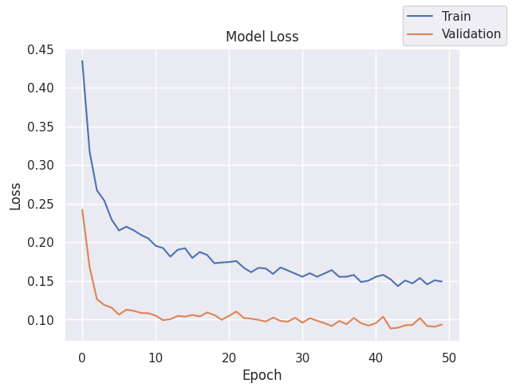

```python
plot(history,'loss')
```

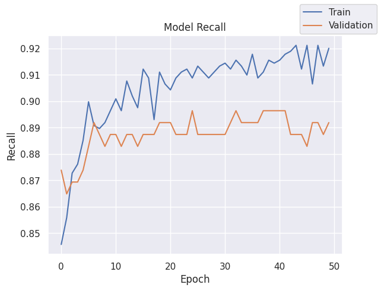

```python
plot(history,'recall')
```

```python
model6_train_perf = model_performance_classification(model6, X_train, y_train)
model6_train_perf
```

```
500/500 ━━━━━━━━━━━━━━━━━━━━ 1s 1ms/step
```

|  | Accuracy | Recall | Precision | F1 Score |
| --- | --- | --- | --- | --- |
| 0 | 0.992062 | 0.992062 | 0.992013 | 0.992035 |

```python
model6_val_perf = model_performance_classification(model6, X_val, y_val)
model6_val_perf
```

```
125/125 ━━━━━━━━━━━━━━━━━━━━ 0s 1ms/step
```

|  | Accuracy | Recall | Precision | F1 Score |
| --- | --- | --- | --- | --- |
| 0 | 0.99125 | 0.99125 | 0.9911 | 0.991126 |

Observations:

# **Model Performance Comparison and Final Model Selection**

Now, in order to select the final model, we will compare the performances of all the models for the training and validation sets.

```python
# training performance comparison

models_train_comp_df = pd.concat(
    [
        model0_train_perf.T,
        model1_train_perf.T,
        model2_train_perf.T,
        model3_train_perf.T,
        model4_train_perf.T,
        model5_train_perf.T,
        model6_train_perf.T
    ],
    axis=1,
)
models_train_comp_df.columns = [
    "Neural Network (SGD, No Regularization)",
    "Neural Network (SGD with Momentum, hidden layer 32 )",
    "Neural Network (Adam , No Regularization, class weight)",
    "Neural Network (Adam, Dropout)",
    "Neural Network (Adam, Batch Normalization)",
    "Neural Network (Adam, No Regularization, hidden layer 128)",
    "Neural Network (Adam, Dropout,He initialization)"
]
```

```python
#Validation performance comparison

models_valid_comp_df = pd.concat(
    [
        model0_val_perf.T,
        model1_val_perf.T,
        model2_val_perf.T,
        model3_val_perf.T,
        model4_val_perf.T,
        model5_val_perf.T,
        model6_val_perf.T
    ],
    axis=1,
)
models_valid_comp_df.columns = [
    "Neural Network (SGD, No Regularization)",
    "Neural Network (SGD with Momentum, hidden layer 32 )",
    "Neural Network (Adam , No Regularization, class weight)",
    "Neural Network (Adam, Dropout)",
    "Neural Network (Adam, Batch Normalization)",
    "Neural Network (Adam, No Regularization, hidden layer 128)",
    "Neural Network (Adam, Dropout,He initialization)"
]
```

```python
models_train_comp_df
```

|  | Neural Network (SGD, No Regularization) | Neural Network (SGD with Momentum, hidden layer 32 ) | Neural Network (Adam , No Regularization, class weight) | Neural Network (Adam, Dropout) | Neural Network (Adam, Batch Normalization) | Neural Network (Adam, No Regularization, hidden layer 128) | Neural Network (Adam, Dropout,He initialization) |
| --- | --- | --- | --- | --- | --- | --- | --- |
| Accuracy | 0.990625 | 0.993938 | 0.993437 | 0.992250 | 0.985563 | 0.994750 | 0.992062 |
| Recall | 0.990625 | 0.993938 | 0.993437 | 0.992250 | 0.985563 | 0.994750 | 0.992062 |
| Precision | 0.990537 | 0.993876 | 0.993360 | 0.992129 | 0.987073 | 0.994721 | 0.992013 |
| F1 Score | 0.990310 | 0.993893 | 0.993379 | 0.992140 | 0.986047 | 0.994657 | 0.992035 |

```python
models_valid_comp_df
```

|  | Neural Network (SGD, No Regularization) | Neural Network (SGD with Momentum, hidden layer 32 ) | Neural Network (Adam , No Regularization, class weight) | Neural Network (Adam, Dropout) | Neural Network (Adam, Batch Normalization) | Neural Network (Adam, No Regularization, hidden layer 128) | Neural Network (Adam, Dropout,He initialization) |
| --- | --- | --- | --- | --- | --- | --- | --- |
| Accuracy | 0.990250 | 0.989250 | 0.990750 | 0.990000 | 0.978500 | 0.990500 | 0.991250 |
| Recall | 0.990250 | 0.989250 | 0.990750 | 0.990000 | 0.978500 | 0.990500 | 0.991250 |
| Precision | 0.990127 | 0.989061 | 0.990573 | 0.989792 | 0.980433 | 0.990315 | 0.991100 |
| F1 Score | 0.989928 | 0.989121 | 0.990576 | 0.989801 | 0.979216 | 0.990332 | 0.991126 |

```python
models_train_comp_df.loc['Recall'] - models_valid_comp_df.loc['Recall']
```

|  | Recall |
| --- | --- |
| Neural Network (SGD, No Regularization) | 0.000375 |
| Neural Network (SGD with Momentum, hidden layer 32 ) | 0.004688 |
| Neural Network (Adam , No Regularization, class weight) | 0.002687 |
| Neural Network (Adam, Dropout) | 0.002250 |
| Neural Network (Adam, Batch Normalization) | 0.007062 |
| Neural Network (Adam, No Regularization, hidden layer 128) | 0.004250 |
| Neural Network (Adam, Dropout,He initialization) | 0.000812 |

**dtype:** float64

Observations:

- Model 0 (0.000375) and Model 6 (.000812)have the smallest gaps which suggests there are excellent at generalization
- Model 6 has a higher training Recall score (0.992062) than Model 0 (0.990625)
- Model 6 has a higher validation Recall score (0.991250) than Model 0 (0.990250)
- The results show that Model 6 is the top candidate with Model 0 a close second.
- We will use Model 6 for performance of the final model.

Now, let's check the performance of the final model on the test set.

```python
# clears the current Keras session, resetting all layers and models previously created, freeing up memory and resources.
tf.keras.backend.clear_session()
```

```python
# initializing the neural network with one hidden layer and activation function of ReLU
model = Sequential()
model.add(Dense(128, activation = 'relu', kernel_initializer='he_normal', input_dim = X_train.shape[1]))
model.add(BatchNormalization())
model.add(Dropout(0.4))
model.add(BatchNormalization())
model.add(Dense(64, activation= 'relu', kernel_initializer='he_normal'))
model.add(Dropout(0.3))
model.add(Dense(32, activation= 'relu', kernel_initializer='he_normal'))
model.add(BatchNormalization())
model.add(Dense(1, activation='sigmoid', kernel_initializer='he_normal'))
```

```python
# printing the summary
model.summary()
```

```
Model: "sequential"
```

```
┏━━━━━━━━━━━━━━━━━━━━━━━━━━━━━━━━━┳━━━━━━━━━━━━━━━━━━━━━━━━┳━━━━━━━━━━━━━━━┓
┃ Layer (type)                    ┃ Output Shape           ┃       Param # ┃
┡━━━━━━━━━━━━━━━━━━━━━━━━━━━━━━━━━╇━━━━━━━━━━━━━━━━━━━━━━━━╇━━━━━━━━━━━━━━━┩
│ dense (Dense)                   │ (None, 128)            │         5,248 │
├─────────────────────────────────┼────────────────────────┼───────────────┤
│ batch_normalization             │ (None, 128)            │           512 │
│ (BatchNormalization)            │                        │               │
├─────────────────────────────────┼────────────────────────┼───────────────┤
│ dropout (Dropout)               │ (None, 128)            │             0 │
├─────────────────────────────────┼────────────────────────┼───────────────┤
│ batch_normalization_1           │ (None, 128)            │           512 │
│ (BatchNormalization)            │                        │               │
├─────────────────────────────────┼────────────────────────┼───────────────┤
│ dense_1 (Dense)                 │ (None, 64)             │         8,256 │
├─────────────────────────────────┼────────────────────────┼───────────────┤
│ dropout_1 (Dropout)             │ (None, 64)             │             0 │
├─────────────────────────────────┼────────────────────────┼───────────────┤
│ dense_2 (Dense)                 │ (None, 32)             │         2,080 │
├─────────────────────────────────┼────────────────────────┼───────────────┤
│ batch_normalization_2           │ (None, 32)             │           128 │
│ (BatchNormalization)            │                        │               │
├─────────────────────────────────┼────────────────────────┼───────────────┤
│ dense_3 (Dense)                 │ (None, 1)              │            33 │
└─────────────────────────────────┴────────────────────────┴───────────────┘
```

```
 Total params: 16,769 (65.50 KB)
```

```
 Trainable params: 16,193 (63.25 KB)
```

```
 Non-trainable params: 576 (2.25 KB)
```

```python
# compile the model
# define the optimizer using Adam
optimizer = keras.optimizers.Adam(learning_rate=0.001)
model.compile(
    loss='binary_crossentropy',
    optimizer=optimizer,
    metrics=[Recall()]
)
```

```python
# time.time() returns the time in seconds
start = time.time()
# Fitting the model.
history = model.fit(X_train, y_train, validation_data=(X_val,y_val) , batch_size=batch_size, epochs=epochs,class_weight=cw_dict)
# time.time() returns the time in seconds
end=time.time()
```

```
250/250 ━━━━━━━━━━━━━━━━━━━━ 5s 7ms/step - loss: 0.5882 - recall: 0.7521 - val_loss: 0.2622 - val_recall: 0.8784
250/250 ━━━━━━━━━━━━━━━━━━━━ 1s 5ms/step - loss: 0.3348 - recall: 0.8573 - val_loss: 0.1822 - val_recall: 0.8649
250/250 ━━━━━━━━━━━━━━━━━━━━ 1s 3ms/step - loss: 0.2785 - recall: 0.8845 - val_loss: 0.1442 - val_recall: 0.8604
250/250 ━━━━━━━━━━━━━━━━━━━━ 1s 3ms/step - loss: 0.2494 - recall: 0.8905 - val_loss: 0.1395 - val_recall: 0.8829
250/250 ━━━━━━━━━━━━━━━━━━━━ 1s 3ms/step - loss: 0.2350 - recall: 0.8878 - val_loss: 0.1317 - val_recall: 0.8874
250/250 ━━━━━━━━━━━━━━━━━━━━ 1s 3ms/step - loss: 0.2141 - recall: 0.9048 - val_loss: 0.1248 - val_recall: 0.8829
250/250 ━━━━━━━━━━━━━━━━━━━━ 1s 3ms/step - loss: 0.2101 - recall: 0.9045 - val_loss: 0.1167 - val_recall: 0.8829
250/250 ━━━━━━━━━━━━━━━━━━━━ 1s 3ms/step - loss: 0.2092 - recall: 0.8949 - val_loss: 0.1189 - val_recall: 0.8874
250/250 ━━━━━━━━━━━━━━━━━━━━ 1s 3ms/step - loss: 0.1842 - recall: 0.9206 - val_loss: 0.1053 - val_recall: 0.8874
250/250 ━━━━━━━━━━━━━━━━━━━━ 1s 3ms/step - loss: 0.1915 - recall: 0.8987 - val_loss: 0.1123 - val_recall: 0.8874
250/250 ━━━━━━━━━━━━━━━━━━━━ 1s 3ms/step - loss: 0.1892 - recall: 0.9076 - val_loss: 0.1062 - val_recall: 0.8874
250/250 ━━━━━━━━━━━━━━━━━━━━ 2s 6ms/step - loss: 0.1812 - recall: 0.9114 - val_loss: 0.1093 - val_recall: 0.8964
250/250 ━━━━━━━━━━━━━━━━━━━━ 1s 6ms/step - loss: 0.1790 - recall: 0.9119 - val_loss: 0.1039 - val_recall: 0.8874
250/250 ━━━━━━━━━━━━━━━━━━━━ 2s 3ms/step - loss: 0.1725 - recall: 0.9101 - val_loss: 0.1065 - val_recall: 0.8919
250/250 ━━━━━━━━━━━━━━━━━━━━ 1s 3ms/step - loss: 0.1734 - recall: 0.9147 - val_loss: 0.1083 - val_recall: 0.8874
250/250 ━━━━━━━━━━━━━━━━━━━━ 1s 3ms/step - loss: 0.1670 - recall: 0.9161 - val_loss: 0.1033 - val_recall: 0.8919
250/250 ━━━━━━━━━━━━━━━━━━━━ 1s 3ms/step - loss: 0.1632 - recall: 0.9246 - val_loss: 0.1019 - val_recall: 0.8919
250/250 ━━━━━━━━━━━━━━━━━━━━ 1s 3ms/step - loss: 0.1634 - recall: 0.9076 - val_loss: 0.1026 - val_recall: 0.8964
250/250 ━━━━━━━━━━━━━━━━━━━━ 1s 3ms/step - loss: 0.1650 - recall: 0.9192 - val_loss: 0.1010 - val_recall: 0.8874
250/250 ━━━━━━━━━━━━━━━━━━━━ 1s 3ms/step - loss: 0.1605 - recall: 0.9129 - val_loss: 0.1007 - val_recall: 0.8919
250/250 ━━━━━━━━━━━━━━━━━━━━ 1s 3ms/step - loss: 0.1555 - recall: 0.9232 - val_loss: 0.0984 - val_recall: 0.8919
250/250 ━━━━━━━━━━━━━━━━━━━━ 1s 3ms/step - loss: 0.1517 - recall: 0.9203 - val_loss: 0.0948 - val_recall: 0.8919
250/250 ━━━━━━━━━━━━━━━━━━━━ 2s 6ms/step - loss: 0.1532 - recall: 0.9180 - val_loss: 0.0947 - val_recall: 0.8919
250/250 ━━━━━━━━━━━━━━━━━━━━ 1s 6ms/step - loss: 0.1467 - recall: 0.9179 - val_loss: 0.0962 - val_recall: 0.8919
250/250 ━━━━━━━━━━━━━━━━━━━━ 2s 3ms/step - loss: 0.1522 - recall: 0.9146 - val_loss: 0.0971 - val_recall: 0.8919
250/250 ━━━━━━━━━━━━━━━━━━━━ 1s 3ms/step - loss: 0.1466 - recall: 0.9149 - val_loss: 0.0939 - val_recall: 0.8919
250/250 ━━━━━━━━━━━━━━━━━━━━ 1s 3ms/step - loss: 0.1360 - recall: 0.9319 - val_loss: 0.0908 - val_recall: 0.8919
250/250 ━━━━━━━━━━━━━━━━━━━━ 1s 3ms/step - loss: 0.1352 - recall: 0.9272 - val_loss: 0.0941 - val_recall: 0.8919
250/250 ━━━━━━━━━━━━━━━━━━━━ 1s 3ms/step - loss: 0.1401 - recall: 0.9221 - val_loss: 0.0919 - val_recall: 0.8919
250/250 ━━━━━━━━━━━━━━━━━━━━ 1s 3ms/step - loss: 0.1401 - recall: 0.9268 - val_loss: 0.0937 - val_recall: 0.8919
250/250 ━━━━━━━━━━━━━━━━━━━━ 1s 3ms/step - loss: 0.1412 - recall: 0.9203 - val_loss: 0.0961 - val_recall: 0.8874
250/250 ━━━━━━━━━━━━━━━━━━━━ 1s 4ms/step - loss: 0.1381 - recall: 0.9190 - val_loss: 0.0951 - val_recall: 0.8919
250/250 ━━━━━━━━━━━━━━━━━━━━ 2s 5ms/step - loss: 0.1337 - recall: 0.9267 - val_loss: 0.0926 - val_recall: 0.8919
250/250 ━━━━━━━━━━━━━━━━━━━━ 2s 6ms/step - loss: 0.1389 - recall: 0.9268 - val_loss: 0.1020 - val_recall: 0.8919
250/250 ━━━━━━━━━━━━━━━━━━━━ 1s 6ms/step - loss: 0.1291 - recall: 0.9284 - val_loss: 0.0944 - val_recall: 0.8919
250/250 ━━━━━━━━━━━━━━━━━━━━ 2s 3ms/step - loss: 0.1289 - recall: 0.9199 - val_loss: 0.0865 - val_recall: 0.8919
250/250 ━━━━━━━━━━━━━━━━━━━━ 1s 3ms/step - loss: 0.1269 - recall: 0.9280 - val_loss: 0.0894 - val_recall: 0.8919
250/250 ━━━━━━━━━━━━━━━━━━━━ 1s 3ms/step - loss: 0.1335 - recall: 0.9244 - val_loss: 0.0872 - val_recall: 0.8919
250/250 ━━━━━━━━━━━━━━━━━━━━ 1s 4ms/step - loss: 0.1304 - recall: 0.9275 - val_loss: 0.0895 - val_recall: 0.8919
250/250 ━━━━━━━━━━━━━━━━━━━━ 1s 4ms/step - loss: 0.1354 - recall: 0.9215 - val_loss: 0.0976 - val_recall: 0.9009
250/250 ━━━━━━━━━━━━━━━━━━━━ 1s 3ms/step - loss: 0.1295 - recall: 0.9271 - val_loss: 0.0935 - val_recall: 0.8919
250/250 ━━━━━━━━━━━━━━━━━━━━ 1s 3ms/step - loss: 0.1296 - recall: 0.9269 - val_loss: 0.0951 - val_recall: 0.8919
250/250 ━━━━━━━━━━━━━━━━━━━━ 1s 3ms/step - loss: 0.1235 - recall: 0.9290 - val_loss: 0.0862 - val_recall: 0.8919
250/250 ━━━━━━━━━━━━━━━━━━━━ 1s 5ms/step - loss: 0.1243 - recall: 0.9312 - val_loss: 0.0867 - val_recall: 0.8919
250/250 ━━━━━━━━━━━━━━━━━━━━ 1s 6ms/step - loss: 0.1357 - recall: 0.9236 - val_loss: 0.0911 - val_recall: 0.8919
250/250 ━━━━━━━━━━━━━━━━━━━━ 2s 3ms/step - loss: 0.1252 - recall: 0.9295 - val_loss: 0.0929 - val_recall: 0.8919
250/250 ━━━━━━━━━━━━━━━━━━━━ 1s 3ms/step - loss: 0.1233 - recall: 0.9342 - val_loss: 0.0883 - val_recall: 0.8919
250/250 ━━━━━━━━━━━━━━━━━━━━ 1s 3ms/step - loss: 0.1155 - recall: 0.9345 - val_loss: 0.0888 - val_recall: 0.8919
250/250 ━━━━━━━━━━━━━━━━━━━━ 1s 3ms/step - loss: 0.1276 - recall: 0.9265 - val_loss: 0.0934 - val_recall: 0.9009
250/250 ━━━━━━━━━━━━━━━━━━━━ 1s 4ms/step - loss: 0.1300 - recall: 0.9272 - val_loss: 0.0916 - val_recall: 0.9054
```

```python
y_train_pred = model.predict(X_train)
y_valid_pred = model.predict(X_val)
y_test_pred = model.predict(X_test)
```

```
500/500 ━━━━━━━━━━━━━━━━━━━━ 1s 1ms/step
125/125 ━━━━━━━━━━━━━━━━━━━━ 0s 1ms/step
157/157 ━━━━━━━━━━━━━━━━━━━━ 0s 2ms/step
```

```python
print("Classification Report - Train data",end="\n\n")
cr = classification_report(y_train,y_train_pred>0.5)
print(cr)
```

```
Classification Report - Train data

              precision    recall  f1-score   support

           0       1.00      0.99      1.00     15112
           1       0.91      0.92      0.92       888

    accuracy                           0.99     16000
   macro avg       0.95      0.96      0.96     16000
weighted avg       0.99      0.99      0.99     16000
```

```python
print("Classification Report - Validation data",end="\n\n")
cr = classification_report(y_val,y_valid_pred>0.5)
print(cr)
```

```
Classification Report - Validation data

              precision    recall  f1-score   support

           0       0.99      0.99      0.99      3778
           1       0.90      0.91      0.90       222

    accuracy                           0.99      4000
   macro avg       0.95      0.95      0.95      4000
weighted avg       0.99      0.99      0.99      4000
```

```python
print("Classification Report - Test data",end="\n\n")
cr = classification_report(y_test,y_test_pred>0.5)
print(cr)
```

```
Classification Report - Test data

              precision    recall  f1-score   support

           0       0.99      0.99      0.99      4718
           1       0.90      0.88      0.89       282

    accuracy                           0.99      5000
   macro avg       0.95      0.94      0.94      5000
weighted avg       0.99      0.99      0.99      5000
```

Observations:

# **Actionable Insights and Recommendations**

- The engineering dapartment at ReneWind should use the Model 6: Neural Network (Adam, Dropout,He initialization) as the final model as it balances generalization and recall best.
- The evaluation metric of Recall is recommended to prioritze minimizing false negatives which would directly reduce the cost of generator replacements.
- The model will help monitor any real world false-negatives as these failures are the most expensive than over predicting a failure. So this model should be integrated with any maintenance scheduling to prioritize inspections.
- There is opportunity for the ReneWind team to utilize techniques to predict machine failure and degradation risks.